# A Principled Bayesian Workflow

Michael Betancourt

June 2018

Given the posterior distribution derived from a probabilistic model and a particular observation, Bayesian inference is straightforward to implement. Inferences, and any decisions based upon them, follow immediately in the form of posterior expectations. Building such a probabilistic model that is satisfactory in a given application, however, is a far more open-ended challenge. Unfortunately the process of model building is only sparsely discussed in the statistics literature, leaving practitioners to piece together their own model building workflow from potentially incomplete or even inconsistent heuristics.

In order to ensure robust analyses we need a *principled* workflow that guides the development of a probabilistic model that is consistent with both our domain expertise and any observed data while also being amenable to accurate computation. In this case study I introduce a principled workflow for building and evaluating probabilistic models in Bayesian inference. This workflow is based on recent research in collaboration with Dan Simpson, Aki Vehtari, Sean Talts, and others; see, for example, Gabry et al. (2017). The specific workflow that I advocated here, however, is my particular take on this research focused on the needs for modeling and inference in the physical sciences. It does not necessarily reflect the perspectives of any of my collaborators and may prove to be limiting in other applications.

Moreover, as this workflow is an active topic of research it is subject to evolution and refinement. Use at your own risk. But at the same time *don’t* use at your own risk. Better yet build a calibrated model, infer the relative risks, and then make a principled decision…

We begin with a discussion of what we desire in a probabilistic model and then I introduce a workflow, emphasizing the role of each step and the expertise needed to implement it well. Once the workflow has been laid out I demonstrate its application on a seemingly simple analysis that hides a few surprises.

# 1 Building a Mystery

What properties characterize a principled probabilistic model? First and foremost the model should be consistent with our domain expertise, capturing not necessarily all of our knowledge of the experimental design but just enough to avoid unreasonable inferences. Such a model then allows us to critique the experimental design itself, including whether or not our computational tools will be sufficient to fit prospective data and whether or not our experimental design admits answers to relevant questions. The utility of these analyses, however, relies on the model being rich enough to learn the structure of the true data generating process beyond our domain expertise, and sometimes in spite of it.

In order to validate a given model we need to ask four questions.

#### Question One: Domain Consistency Expertise

*Are the assumptions inherent in our model consistent with the relevant elements of our domain expertise?*

#### Question Two: Computational Faithfulness

*Are our computational tools sufficient to accurately fit the model?*

#### Question Three: Model Sensitivity

*How do we expect our inferences to perform over the distribution of reasonable observations?*

#### Question Four: Practical Model Validity

*Is our model rich enough to capture the relevant structure of the true data generating process?*

The first three questions are asked before our measurement process resolves to a particular observation, considering instead the robustness of the model to the possible observations. Even if we our observation is immediately available, however, these questions are important in understanding how to safely utilize resulting inferences. The final question is asked once the observed data is available and the resulting inferences have been constructed.

The ultimate goal of a principled Bayesian workflow is to answer these questions, hopefully confirming each in turn before moving on to the next. In practice, however, answering these questions will identify deficiencies in the initial model that will need to be resolved before restarting the workflow.

# 2 Work it, Make it, Do it, Makes Us Harder, Better, Faster, Stronger

The workflow proposed here begins by exploring and quantifying our domain expertise in the context of a given analysis before developing an initial model. We next consider the holistic consequences of that model, spanning inferential and computational considerations, without reference to a particular observation in order to answer the first three questions. Once those consequences have been understood and deemed acceptable the model is applied to a particular observation and the corresponding inferences critiqued. If the model is judged insufficient to capture the relevant structure in observed data then it must be expanded, at which point we begin the workflow anew for the expanded model.

Here *domain expertise* refers to the experience of those responsible for collecting, curating, or otherwise manipulating the data as well as stakeholders who will make decisions using the final inferences or any intermediaries who will help stakeholders to make those decisions. *Statistical expertise* refers to proficiency in probabilistic modeling and computation.

## Step One: Conceptual Analysis

Our first step is to conceptually model the observational process from the latent phenomenon being studied through its interactions with the environment and how those interactions manifest as observations. We want to pay particular attention to the many possible systematic effects that influence this process but are not known with complete certainty. This conceptual analysis yields informal narratives describing how observations are generated.

**Requirements:** Domain Expertise

## Step Two: Define Observations

Once a conceptual model has been developed we can take our first steps towards building a formal mathematical model by defining the space in which observations take values. This may include, for example, the number of repetitions, subjects, groups, or components in each observation as well as the range of values each component can take.

**Requirements:** Domain Expertise and Statistical Expertise

## Step Three: Identify Relevant Summary Statistics

Given an observation space we can now identify summary statistics that isolate particularly important properties of the experimental design, especially those details that are relevant to decision making and those that are expected to be difficult to model well. By identifying the relevant structures within the observation space these summary statistics provide the basis for quantifying Question One and Question Four. In practice such summary statistics are typically given by one or two dimensional functions amenable to visualization.

We also want to complement these summary statistics with conceptual expectations for what behaviors are reasonable, or, as is often easier to elicit in practice, what behaviors are *unreasonable*.

**Requirements:** Domain Expertise

## Step Four: Build a Generative Model

With the observation space defined and scrutinized we can proceed to build and then analyze a full generative model of the observation process.

### Build a Generative Observation Model

First we construct a generative model of the observation process, $\pi(y \mid \theta)$. An ideal generative model is readily interpretable as a collection of mathematical narratives of how an observation is produced based on a given model configuration, $\theta$, translating the conceptual narrative produced in Step One into a rigorous probabilistic model.

Often the generative observation model is a crude approximation to the complexity of the true measurement process, but crude approximations are often sufficient to answer even sophisticated questions. Still, we want to keep the approximate nature of our model in mind and consider also various extensions of the model, for example heterogeneities, time dependences, and other systematic effects.

**Requirements:** Domain Expertise and Statistical Expertise

### Complete The Full Generative Model By Specifying Priors

We complete the generative model by complementing the observation model with a prior distribution for all unknown model configuration parameters, $\pi(\theta)$. In particular we want to reason about the *scales* of these parameters to motivate a prior distribution that incorporates enough information to ensure that the full generative model,
$$\pi(y, \theta) = \pi(y \mid \theta) \, \pi(\theta),$$
is well-behaved (Gelman, Simpson, and Betancourt 2017).

Keep in mind that the separation of the generative model into an observation process and a prior distribution is not uniquely defined in a Bayesian model. Consider, for example, unobserved latent structure, $\pi(\theta \mid \phi)$, such as that arising in hierarchical models and hidden Markov models. We could equally well define the observation model as $\pi(y \mid \theta) \, \pi(\theta \mid \phi)$ with the prior distribution $\pi(\phi)$, or the observation model as $\pi(y \mid \theta)$ with the prior distribution $\pi(\theta \mid \phi) \, \pi(\phi)$. Only the full generative model is uniquely defined.

Consequently the focus here should be not on specifying prior distributions in isolation but rather *completing* the observation model developed above with probabilistic structure for the model configuration parameters as needed. This might take the form of independent, one-dimensional prior distributions for each parameter or more sophisticated correlated distributions which introduce their own parameters that require another round of prior distributions. It’s probability distributions all the way down.

**Requirements:** Domain Expertise and Statistical Expertise

## Step Five: Analyze the Generative Ensemble

Before drawing inferences from a given observation we first want to analyze the scope of our generative model and compare to our domain expertise in order to provide some answer to Question One, Question Two, and Question Three.

To do that we first simulate parameters *and* observations from the complete generative model. Specifically, we simulate and then analyze ground truths from the prior and observations from the corresponding observation model,
$$\begin{align*}
\tilde{\theta} &\sim \pi(\theta)
\\
\tilde{y} &\sim \pi(y \mid \tilde{\theta} ),
\end{align*}$$

**Requirements:** Statistical Expertise

### Analyze the Prior Predictive Distribution

Analyzing the distribution of summary statistics constructed in Step Three for the simulated observations provides a natural evaluation of our modeling assumptions within the context of our domain expertise, answering Question One. This technique goes back to Good’s *device of imaginary results* (Good 1950), which also gives its user a +2 to Wisdom saving throws.

If the behavior of the summary statistics for these simulated observations is not within the conceptual expectations defined in Step Three then we need to return to Step Four and incorporate additional prior information to restrict the scope of model to reasonable behaviors.

**Requirements:** Domain Expertise

### Fit the Simulated Observations and Evaluate

For each simulated observation we can also attempt to construct a posterior distribution, $\pi(\theta \mid \tilde{y})$, with a given computational method and analyze the range of possible inferences (Betancourt 2018) in order to answer Question Two and Question Three.

#### Evaluate Diagnostics

If diagnostics of the given computational method, such as $\hat{R}$ for Markov chain Monte Carlo and divergences for Hamiltonian Monte Carlo, indicate inaccuracies in these fits then we need to consider retuning the method, or selecting another method altogether, and then repeating Step Five.

Correlating poor performance with the corresponding simulated ground truth can also help to identify regions of the model configuration space that may be ill-posed for practical computation. These pathological behaviors imply extreme behavior in the posterior which often hints at tension between the model and our domain expertise.

**Requirements:** Statistical Expertise

#### Evaluate Prior-Posterior Consistency

If the computational method generates posterior samples,
$$\tilde{\theta}' \sim \pi(\theta \mid \tilde{y}),$$
then the ensemble of all posterior samples over the simulated ground truths and observations will be indistinguishable from any sample from the prior distribution.

This allows us to verify a given computational method using *simulated-based calibration* (Talts et al. 2018). If performance is unsatisfactory then we need to consider retuning the method, or selecting another method altogether and then repeating Step Five.

**Requirements:** Statistical Expertise

#### Analyze Posterior Behaviors

Assuming that we are accurately recovering posteriors across all of the simulated observations then we can proceed to analyze the range of behaviors in these posteriors. For example, the *posterior $z$-score* of a given parameter,
$$z = \left|
\frac{ \mu_{\mathrm{post}} - \tilde{\theta} }
{ \sigma_{\mathrm{post}} } \right|$$
quantifies how accurately the posterior recovers the ground truth with smaller values indicating more accurate posteriors. At the same time the *posterior shrinkage*,
$$s = 1 -
\frac{ \sigma^{2}_{\mathrm{post}} }
{ \sigma^{2}_{\mathrm{prior}} },$$
quantifies how much the posterior learns from a given observation. Shrinkage near zero indicates that the data provide little information beyond that encoded in the prior distribution while shrinkage near one indicates highly informative observations.

If there are indications of undesired posterior behavior, such as overfitting or non-identifiability, then we need to return to Step One and consider an improved experimental design or return to Step Four and incorporate additional prior information to restrict the scope of model to reasonable behaviors.

**Requirements:** Statistical Expertise

#### Analyzing Posterior-Informed Decisions

If a posterior-informed decision-making process has been established then we can calibrate the performance of this process by comparing the decision derived from each posterior relative to the corresponding simulated ground truth. For example, if a discovery claim has to be made then we at the very least want to compute the corresponding false discovery rate and true discovery rate within the context of our generative model.

If the performance of the decision-making progress is insufficient then we need to return to Step One and consider an improved experimental design or possibly return to Step Four and incorporate additional prior information to restrict the scope of model to reasonable behaviors.

**Requirements:** Domain Expertise and Statistical Expertise

## Step Six: Fit the Observations and Evaluate

Once computation, inferences, and decision-making processes have been validated within the scope of the model assumptions, the analysis can be applied to the observed data and we can confront Question Four. Analysis of the resulting inference may suggest expanding the model, but any changes to the model after looking at the data introduce a vulnerability to overfitting and so we must be extremely vigilant to study the ensemble behavior in subsequent iterations of the workflow.

Confident that we understand the consequence of our probabilistic model we can construct a posterior distribution from a given observation. We have to be careful, however, as the previous validation of the computational method may not apply if the observed data is not within the scope of the generative model. Consequently we need to be careful to check any diagnostics of our method.

If any diagnostics indicate poor performance then not only is our computational method suspect but also our generative model may not be rich enough to capture the relevant details of the observed data. At the very least we should reconsider the tuning of our computational tools, but we may also want to consider going back to Step Four and expanding our model so that it better captures the observation.

**Requirements:** Statistical Expertise

## Step Seven: Analyze the Posterior Predictive Distribution

Even if we are able to compute a posterior accurately there is no guarantee that our model captures the complexity of the given observation.

In order to verify the sufficiency of our model and answer Question Four we need to compare the observation to the *posterior predictive distribution* (Betancourt 2015). We can achieve this verification similar to the device of imaginary results discussed in Step Five, only simulating observations from the observational process conditioned on posterior samples,
$$\begin{align*}
\tilde{\theta}' &\sim \pi(\theta \mid y)
\\
\tilde{y} &\sim \pi(y \mid \tilde{\theta}' ).
\end{align*}$$

As with Step Five we evaluate the summary statistics defined in Step Three at the posterior predictive samples to generate a distribution, only this time we compare the distribution to the observed data in a *posterior predictive check* (Rubin 1984). If there is strong disagreement then we need to go back to Step Four and elaborate the components of the generative model that influence those summary statistics manifesting disagreement. We may even need to go back to Step One and improve our domain expertise of the experimental design before considering an expanded model. Once we have a new model we then restart the workflow and iterate until we can’t identify any deviations from the model and our observation and our domain expertise.

In order to avoid overfitting to the observed data in this iterative model expansion we have to be careful to not abuse the particular structure of the observed data. We don’t want to respond to failing posterior predictive checks by incorporating quantitative features of the observed data into the model but rather expanding the model within the scope of our, possibly improved, domain expertise. For example, we don’t want to respond to our posterior predictive checks by adding a new component to our model with particular values but rather a new component with uncertain values to be fit jointly with the rest of the model.

**Requirements:** Domain Expertise and Statistical Expertise

# 3 Close Enough For An Effective Demonstration

In order to demonstrate the proposed workflow let’s a consider a relatively simple example of an analysis that might arise in any science lab. We have been tasked with analyzing data collected by a precocious young student who was instructed to train a suite of detectors onto a specimen that emits a constant flow of particles. They dutifully collected data and collated it into a file which has arrived in our inbox.

Before evening reading the email we set up our local `R` environment.

```r
library(rstan)
rstan_options(auto_write = TRUE)

library(foreach)
library(doParallel)
util <- new.env()
source('stan_utility.R', local=util)

c_light <- c("#DCBCBC")
c_light_highlight <- c("#C79999")
c_mid <- c("#B97C7C")
c_mid_highlight <- c("#A25050")
c_dark <- c("#8F2727")
c_dark_highlight <- c("#7C0000")
```

## 3.1 First Iteration: A Journey of a Thousand Models Begins with a Single Step

In our first iteration through the workflow we model the experiment that we’ve been told occurred. Nothing ominous here.

### Step One: Conceptual Analysis

Our conceptual model follows the instructions given to the student. 1000 detectors were directed towards the source and set to record the number of incident particles over a given interval of time. The intensity of the source is presumed to be constant over that interval and each detector should be identical in operation.

### Step Two: Define Observations

Mathematically our observation takes the form of integer counts, $y$, for each of the $N = 1000$ detectors. In the Stan modeling language this is specified as

```r
writeLines(readLines("fit_data.stan", n=4))
```

```
data {
  int N;
  int y[N];
}
```

### Step Three: Identify Relevant Summary Statistics

There are $N = 1000$ components in each observation, one for each detector. We could analyze each component independently but, because we have assumed that the detectors are all identical, we can analyze their comprehensive responses with a histogram of their counts. In other words we consider the histogram of detector counts *as the summary statistic*!

Here we assume that our conceptual domain expertise would inform us that 25 counts in a detector would be an extreme but not impossible observation.

### Step Four: Build a Generative Model

The constant intensity of the source and detector response suggest a Poisson observation model for each of the detectors with a single source strength, $\lambda$.

Our domain expertise that 25 counts is extreme suggests that we want our prior for $\lambda$ to keep most of its probability mass below $\lambda = 15$, which corresponds to fluctuations in the observations around $15 + 3 \sqrt{15} \approx 25$. We achieve this with a half-normal prior with standard deviation = 6.44787 such that only 1% of the prior probability mass is above $\lambda = 15$.

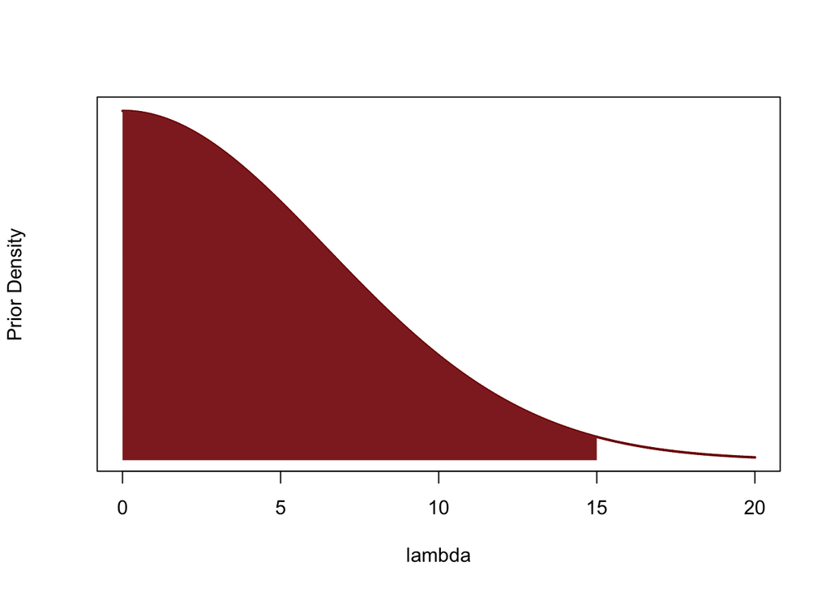

```r
lambda <- seq(0, 20, 0.001)

plot(lambda, dnorm(lambda, 0, 6.44787), type="l", col=c_dark_highlight, lwd=2,
     xlab="lambda", ylab="Prior Density", yaxt='n')

lambda99 <- seq(0, 15, 0.001)
dens <- dnorm(lambda99, 0, 6.44787)
lambda99 <- c(lambda99, 15, 0)
dens <- c(dens, 0, 0)

polygon(lambda99, dens, col=c_dark, border=NA)
```

This probabilistic model is implemented in the Stan programs

```r
writeLines(readLines("generative_ensemble.stan"))
```

```
data {
  int N;
}

generated quantities {
  real<lower=0> lambda = fabs(normal_rng(0, 6.44787));
  int y[N];
    for (n in 1:N) y[n] = poisson_rng(lambda);
}
```

```r
writeLines(readLines("fit_data.stan"))
```

```
data {
  int N;
  int y[N];
}

parameters {
  real<lower=0> lambda;
}

model {
  lambda ~ normal(0, 6.44787);
  y ~ poisson(lambda);
}
```

### Step Five: Analyze the Generative Ensemble

Here we will consider $R = 1000$ draws from the generative ensemble, each of which simulates a ground truth and observed values for the $N = 1000$ detectors.

```r
R <- 1000
N <- 1000

simu_data <- list("N" = N)

fit <- stan(file='generative_ensemble.stan', data=simu_data,
            iter=R, warmup=0, chains=1, refresh=R,
            seed=4838282, algorithm="Fixed_param")
```

```
Iteration:   1 / 1000 [  0%]  (Sampling)
Iteration: 1000 / 1000 [100%]  (Sampling)

 Elapsed Time: 0 seconds (Warm-up)
               0.104232 seconds (Sampling)
               0.104232 seconds (Total)
```

```r
simu_lambdas <- extract(fit)$lambda
simu_ys <- extract(fit)$y
```

More draws from the generative ensemble will yield a more precise understanding of the model and I recommend that you run as many replications as your computational resources allow. In circumstances with limited computational resources, however, even a few replications can provide a powerful view into the consequences of your model.

#### Analyze the Prior Predictive Distribution

We can visualize the prior predictive distribution of histogram counts with quantiles of the bin counts over the generative replications. Here the darkest red corresponds to the bin medians with the increasingly lighter bands corresponding to $(0.4, 0.6)$, $(0.3, 0.7)$, $(0.2, 0.8)$, and $(0.1, 0.9)$ intervals, respectively. This visualization can obscure correlations amongst the bins, but it serves as a useful summary of the full prior predictive distribution.

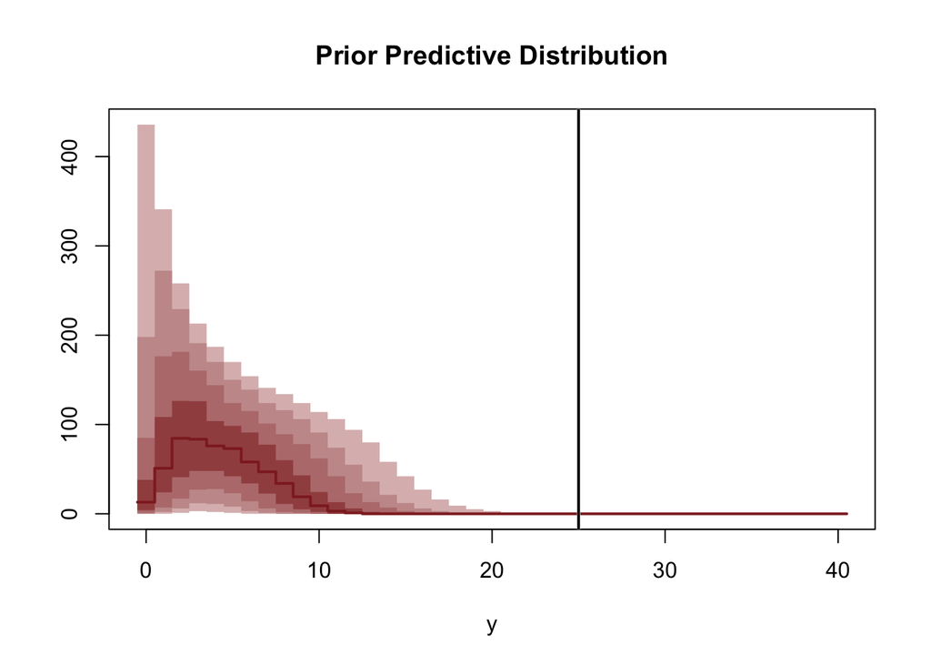

```r
B <- 40
counts <- sapply(1:R, function(r) hist(simu_ys[r,], breaks=(0:(B + 1))-0.5, plot=FALSE)$counts)
probs = c(0.1, 0.2, 0.3, 0.4, 0.5, 0.6, 0.7, 0.8, 0.9)
cred <- sapply(1:(B + 1), function(b) quantile(counts[b,], probs=probs))

idx <- rep(0:B, each=2)
x <- sapply(1:length(idx), function(b) if(b %% 2 == 0) idx[b] + 0.5 else idx[b] - 0.5)
pad_cred <- do.call(cbind, lapply(idx, function(n) cred[1:9,n + 1]))

plot(1, type="n", main="Prior Predictive Distribution",
     xlim=c(-0.5, B + 0.5), xlab="y", ylim=c(0, max(cred[9,])), ylab="")

polygon(c(x, rev(x)), c(pad_cred[1,], rev(pad_cred[9,])),
        col = c_light, border = NA)
polygon(c(x, rev(x)), c(pad_cred[2,], rev(pad_cred[8,])),
        col = c_light_highlight, border = NA)
polygon(c(x, rev(x)), c(pad_cred[3,], rev(pad_cred[7,])),
        col = c_mid, border = NA)
polygon(c(x, rev(x)), c(pad_cred[4,], rev(pad_cred[6,])),
        col = c_mid_highlight, border = NA)
lines(x, pad_cred[5,], col=c_dark, lwd=2)

abline(v=25, col="white", lty=1, lw=2.5)
abline(v=25, col="black", lty=1, lw=2)
```

Indeed we see a very small prior predictive probability for observations above the extreme scale informed by our domain expertise.

```r
length(simu_ys[simu_ys > 25]) / length(simu_ys)
```

```
[1] 0.000933
```

#### Fit the Simulated Observations and Evaluate

Now we are ready to generate and analyze inferences from each of our replications. Because each replication can be analyzed independently this analysis is embarrassingly parallel which allows us to exploit the increasingly common parallel computing resources.

Because this particular model can be fit so quickly I am parallelizing over replications instead of, say, parallelizing the Markov chains run to fit each replication. The optimal setup in any given analysis will depend on the details of the computational circumstances.

```r
tryCatch({
  registerDoParallel(makeCluster(detectCores()))

  simu_list <- t(data.matrix(data.frame(simu_lambdas, simu_ys)))

  # Compile the posterior fit model
  fit_model = stan_model(file='fit_data.stan')

  ensemble_output <- foreach(simu=simu_list,
                             .combine='cbind') %dopar% {
    simu_lambda <- simu[1]
    simu_y <- simu[2:(N + 1)];

    # Fit the simulated observation
    input_data <- list("N" = N, "y" = simu_y)

    capture.output(library(rstan))
    capture.output(fit <- sampling(fit_model, data=input_data, seed=4938483))

    # Compute diagnostics
    util <- new.env()
    source('stan_utility.R', local=util)

    warning_code <- util$check_all_diagnostics(fit, quiet=TRUE)

    # Compute rank of prior draw with respect to thinned posterior draws
    sbc_rank <- sum(simu_lambda < extract(fit)$lambda[seq(1, 4000 - 8, 8)])

    # Compute posterior sensitivities
    s <- summary(fit, probs = c(), pars='lambda')$summary
    post_mean_lambda <- s[,1]
    post_sd_lambda <- s[,3]

    prior_sd_lambda <- 6.44787

    z_score <- abs((post_mean_lambda - simu_lambda) / post_sd_lambda)
    shrinkage <- 1 - (post_sd_lambda / prior_sd_lambda)**2

    c(warning_code, sbc_rank, z_score, shrinkage)
  }
}, finally={ stopImplicitCluster() })
```

The first thing we do is check the diagnostics to make sure that each fit is accurately representing the corresponding posterior distribution.

```r
warning_code <- ensemble_output[1,]
if (sum(warning_code) != 0) {
  print ("Some simulated posterior fits in the generative ensemble encountered problems!")
  for (r in 1:R) {
    if (warning_code[r] != 0) {
      print(sprintf('Replication %s of %s', r, R))
      util$parse_warning_code(warning_code[r])
      print(sprintf('Simulated lambda = %s', simu_lambdas[r]))
      print(" ")
    }
  }
} else {
  print ("No posterior fits in the generative ensemble encountered problems!")
}
```

```
[1] "No posterior fits in the generative ensemble encountered problems!"
```

Fortunately there are no signs of any problems.

We can provide an even stronger guarantee that our fits are accurate by applying simulation-based calibration (SBC).

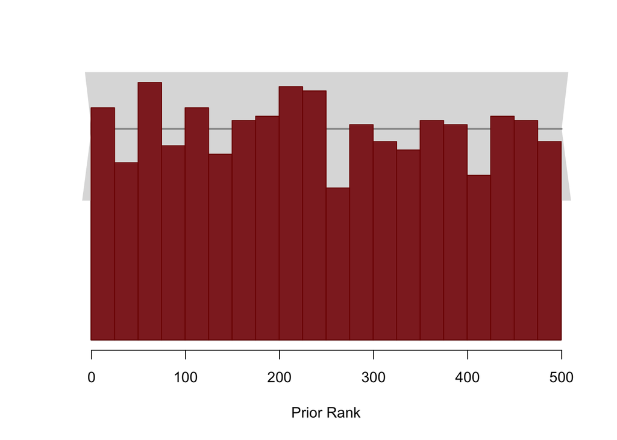

```r
sbc_rank <- ensemble_output[2,]
sbc_hist <- hist(sbc_rank, seq(0, 500, 25) - 0.5,
                 col=c_dark, border=c_dark_highlight, plot=FALSE)
plot(sbc_hist, main="", xlab="Prior Rank", yaxt='n', ylab="")

low <- qbinom(0.005, R, 1 / 20)
mid <- qbinom(0.5, R, 1 / 20)
high <- qbinom(0.995, R, 1 / 20)
bar_x <- c(-10, 510, 500, 510, -10, 0, -10)
bar_y <- c(high, high, mid, low, low, mid, high)

polygon(bar_x, bar_y, col=c("#DDDDDD"), border=NA)
segments(x0=0, x1=500, y0=mid, y1=mid, col=c("#999999"), lwd=2)

plot(sbc_hist, col=c_dark, border=c_dark_highlight, add=T)
```

The variations in the SBC histogram are within the expectations of uniformity shown in the grey bar, which suggests that the fits are indeed faithfully representing the true posterior distributions.

Confident in our fits we can then analyze the posterior distributions themselves.

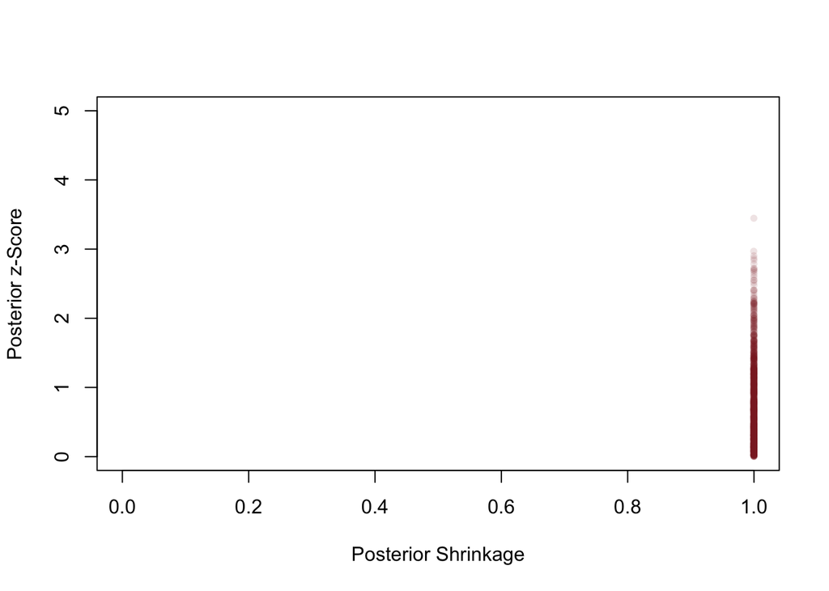

```r
z_score <- ensemble_output[3,]
shrinkage <- ensemble_output[4,]

plot(shrinkage, z_score, col=c("#8F272720"), lwd=2, pch=16, cex=0.8,
     xlim=c(0, 1), xlab="Posterior Shrinkage",
     ylim=c(0, 5), ylab="Posterior z-Score")
```

Agreeably the concentration towards large shrinkage indicates that all of our the posteriors in the generative ensemble are well-identified, and the concentration towards small $z$-scores indicates that they accurately capture the corresponding ground truth.

### Step Six: Fit the Observations and Evaluate

Confident that our model captures our domain expertise and is well-behaved within the scope of its own assumptions we can fire up our email client and grab the student’s data.

```r
input_data <- read_rdump('workflow.data.R')
fit <- stan(file='fit_data_ppc.stan', data=input_data,
            seed=4938483, refresh=2000)
```

[output not shown]

The fit shows no diagnostic problems,

[output not shown]

and the recovered posterior looks reasonable.

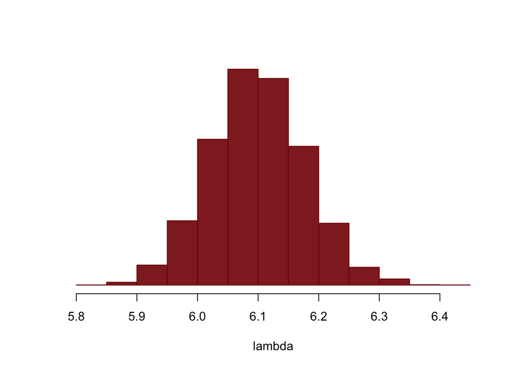

```r
params = extract(fit)

hist(params$lambda, main="", xlab="lambda", yaxt='n', ylab="",
     col=c_dark, border=c_dark_highlight)
```

### Step Seven: Analyze the Posterior Predictive Distribution

But how well does our model capture the structure of the data? To perform a posterior predictive check we compare the observed histogram of counts to the posterior predictive distribution of counts, here visualized with marginal bin quantiles as we did for the prior predictive distribution.

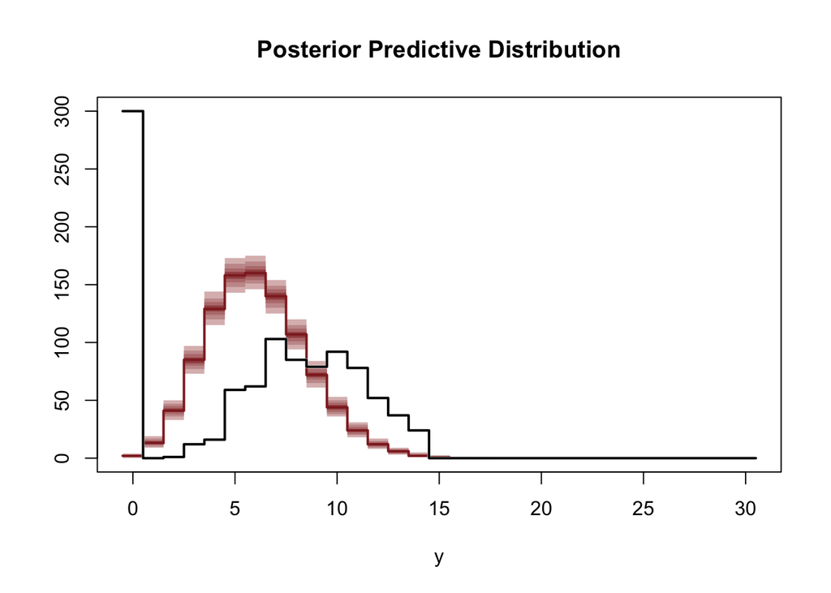

```r
B <- 30

obs_counts <- hist(input_data$y, breaks=(0:(B + 1))-0.5, plot=FALSE)$counts

idx <- rep(0:B, each=2)
x <- sapply(1:length(idx), function(b) if(b %% 2 == 0) idx[b] + 0.5 else idx[b] - 0.5)
pad_obs <- do.call(cbind, lapply(idx, function(n) obs_counts[n + 1]))

counts <- sapply(1:4000, function(n) hist(params$y_ppc[n,], breaks=(0:(B + 1))-0.5, plot=FALSE)$counts)
probs = c(0.1, 0.2, 0.3, 0.4, 0.5, 0.6, 0.7, 0.8, 0.9)
cred <- sapply(1:(B + 1), function(b) quantile(counts[b,], probs=probs))
pad_cred <- do.call(cbind, lapply(idx, function(n) cred[1:9,n + 1]))

plot(1, type="n", main="Posterior Predictive Distribution",
     xlim=c(-0.5, B + 0.5), xlab="y",
     ylim=c(0, max(c(obs_counts, cred[9,]))), ylab="")

polygon(c(x, rev(x)), c(pad_cred[1,], rev(pad_cred[9,])),
        col = c_light, border = NA)
polygon(c(x, rev(x)), c(pad_cred[2,], rev(pad_cred[8,])),
        col = c_light_highlight, border = NA)
polygon(c(x, rev(x)), c(pad_cred[3,], rev(pad_cred[7,])),
        col = c_mid, border = NA)
polygon(c(x, rev(x)), c(pad_cred[4,], rev(pad_cred[6,])),
        col = c_mid_highlight, border = NA)
lines(x, pad_cred[5,], col=c_dark, lwd=2)

lines(x, pad_obs, col="white", lty=1, lw=2.5)
lines(x, pad_obs, col="black", lty=1, lw=2)
```

Unfortunately the posterior predictive check indicates a serious excess of zeros above what we’d expect from Poissonian observations alone. Our model is not flexible enough to capture both the peak at zero and the bulk away from zero, instead trying to compromise between these two behavior and capturing neither particularly well. This experiment isn’t quite as simple as it first appeared.

## 3.2 Second Iteration: If At First You Don’t Succeed, Try Try Again

The conflict between the observation and the model prediction we saw in the posterior predictive check immediately suggests an expanded model, and a second iteration of our workflow.

### Step One: Conceptual Analysis

The excess of zeroes suggests that the detectors are not all in perfect working order. Some apparently return zero counts regardless of the flux of incident particles.

Fortunately we can readily capture this possibility with a *zero-inflated Poisson* model that mixes a Poisson distribution with a point distribution that concentrates entirely at zero.

### Step Two: Define Observations

The observation space does not change in our expanded model.

```r
writeLines(readLines("fit_data2.stan", n=4))
```

```
data {
  int N;
  int y[N];
}
```

### Step Three: Identify Relevant Summary Statistics

The same histogram summary from before will still be useful with the addition of zero inflation in our model.

### Step Four: Build a Generative Model

Our generative model expands to model excess zeroes by mixing the Poisson distribution with a Dirac distribution at zero. We use the same prior for the source intensity, $\lambda$, and assign a uniform prior over the mixture weight, $\theta$.

This expanded model is implemented in the Stan programs

```r
writeLines(readLines("generative_ensemble2.stan"))
```

```
data {
  int N;
}

generated quantities {
  real<lower=0, upper=1> theta = beta_rng(1, 1);
  real<lower=0> lambda = fabs(normal_rng(0, 6.44787));

  int y[N] = rep_array(0, N);
  for (n in 1:N)
    if (!bernoulli_rng(theta))
      y[n] = poisson_rng(lambda);
}
```

```r
writeLines(readLines("fit_data2.stan"))
```

```
data {
  int N;
  int y[N];
}

parameters {
  real<lower=0, upper=1> theta;
  real<lower=0> lambda;
}

model {
  theta ~ beta(1, 1);
  lambda ~ normal(0, 6.44787);

  for (n in 1:N) {
    real lpdf = poisson_lpmf(y[n] | lambda);
    if (y[n] == 0)
      target += log_mix(theta, 0, lpdf);
    else
      target += log1m(theta) + lpdf;
  }
}
```

### Step Five: Analyze the Generative Ensemble

The structure of our generative ensemble doesn’t change.

```r
R <- 1000
N <- 1000

simu_data <- list("N" = N)

fit <- stan(file='generative_ensemble2.stan', data=simu_data,
            iter=R, warmup=0, chains=1, refresh=R,
            seed=4838282, algorithm="Fixed_param")
```

```
Iteration:   1 / 1000 [  0%]  (Sampling)
Iteration: 1000 / 1000 [100%]  (Sampling)

 Elapsed Time: 0 seconds (Warm-up)
               0.082257 seconds (Sampling)
               0.082257 seconds (Total)
```

```r
simu_lambdas <- extract(fit)$lambda
simu_thetas <- extract(fit)$theta
simu_ys <- extract(fit)$y
```

#### 3.2.0.1 Analyze the Prior Predictive Distribution

The average prior predictive histogram now manifests the zero-inflation we have added to our model.

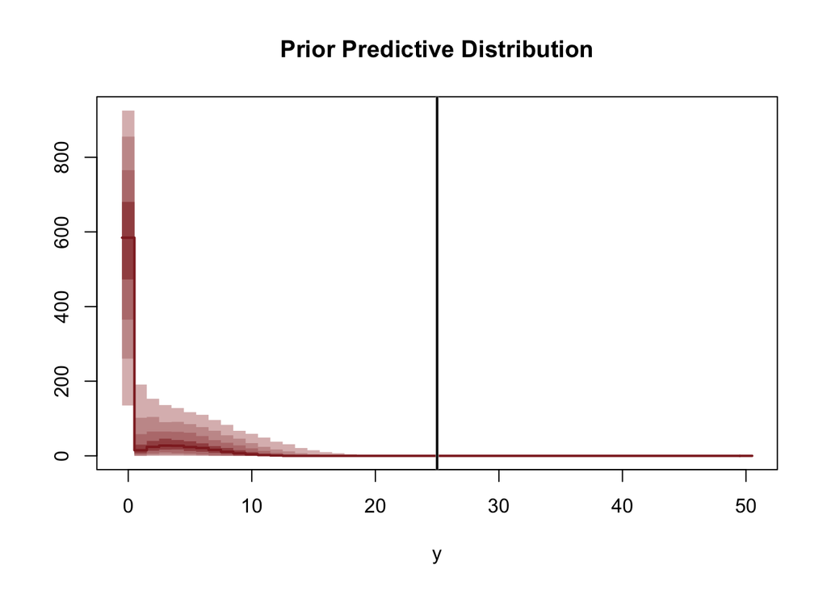

```r
B <- 50
counts <- sapply(1:R, function(r) hist(simu_ys[r,], breaks=(0:(B + 1))-0.5, plot=FALSE)$counts)
probs = c(0.1, 0.2, 0.3, 0.4, 0.5, 0.6, 0.7, 0.8, 0.9)
cred <- sapply(1:(B + 1), function(b) quantile(counts[b,], probs=probs))

idx <- rep(0:B, each=2)
x <- sapply(1:length(idx), function(b) if(b %% 2 == 0) idx[b] + 0.5 else idx[b] - 0.5)
pad_cred <- do.call(cbind, lapply(idx, function(n) cred[1:9,n + 1]))

plot(1, type="n", main="Prior Predictive Distribution",
     xlim=c(-0.5, B + 0.5), xlab="y", ylim=c(0, max(cred[9,])), ylab="")

polygon(c(x, rev(x)), c(pad_cred[1,], rev(pad_cred[9,])),
        col = c_light, border = NA)
polygon(c(x, rev(x)), c(pad_cred[2,], rev(pad_cred[8,])),
        col = c_light_highlight, border = NA)
polygon(c(x, rev(x)), c(pad_cred[3,], rev(pad_cred[7,])),
        col = c_mid, border = NA)
polygon(c(x, rev(x)), c(pad_cred[4,], rev(pad_cred[6,])),
        col = c_mid_highlight, border = NA)
lines(x, pad_cred[5,], col=c_dark, lwd=2)

abline(v=25, col="white", lty=1, lw=2.5)
abline(v=25, col="black", lty=1, lw=2)
```

This addition, however, doesn’t change the tail of observations and hence we still have an appropriately small prior predictive probability for extreme counts.

```r
length(simu_ys[simu_ys > 25]) / length(simu_ys)
```

```
[1] 0.000231
```

#### Fit the Simulated Observations and Evaluate

We now proceed to fitting each replication.

```r
tryCatch({
  registerDoParallel(makeCluster(detectCores()))

  simu_list <- t(data.matrix(data.frame(simu_lambdas, simu_thetas, simu_ys)))

  # Compile the posterior fit model
  fit_model = stan_model(file='fit_data2.stan')

  ensemble_output <- foreach(simu=simu_list,
                             .combine='cbind') %dopar% {
    simu_lambda <- simu[1]
    simu_theta <- simu[2]
    simu_y <- simu[3:(N + 2)];

    # Fit the simulated observation
    input_data <- list("N" = N, "y" = simu_y)

    capture.output(library(rstan))
    capture.output(fit <- sampling(fit_model, data=input_data, seed=4938483))

    # Compute diagnostics
    util <- new.env()
    source('stan_utility.R', local=util)

    warning_code <- util$check_all_diagnostics(fit, quiet=TRUE)

    # Compute rank of prior draw with respect to thinned posterior draws
    sbc_rank_lambda <- sum(simu_lambda < extract(fit)$lambda[seq(1, 4000 - 8, 8)])
    sbc_rank_theta <- sum(simu_theta < extract(fit)$theta[seq(1, 4000 - 8, 8)])

    # Compute posterior sensitivities
    s <- summary(fit, probs = c(), pars='lambda')$summary
    post_mean_lambda <- s[,1]
    post_sd_lambda <- s[,3]

    prior_sd_lambda <- 6.44787

    z_score_lambda <- abs((post_mean_lambda - simu_lambda) / post_sd_lambda)
    shrinkage_lambda <- 1 - (post_sd_lambda / prior_sd_lambda)**2

    s <- summary(fit, probs = c(), pars='theta')$summary
    post_mean_theta <- s[,1]
    post_sd_theta <- s[,3]

    prior_sd_theta <- sqrt(1.0 / 12)

    z_score_theta <- abs((post_mean_theta - simu_theta) / post_sd_theta)
    shrinkage_theta <- 1 - (post_sd_theta / prior_sd_theta)**2

    c(warning_code,
      sbc_rank_lambda, z_score_lambda, shrinkage_lambda,
      sbc_rank_theta, z_score_theta, shrinkage_theta)
  }
}, finally={ stopImplicitCluster() })
```

Our first step is to check the fit diagnostics for each replication.

```r
warning_code <- ensemble_output[1,]
if (sum(warning_code) != 0) {
  print ("Some simulated posterior fits in the generative ensemble encountered problems!")
  for (r in 1:R) {
    if (warning_code[r] != 0) {
      print(sprintf('Replication %s of %s', r, R))
      util$parse_warning_code(warning_code[r])
      print(sprintf('Simulated lambda = %s', simu_lambdas[r]))
      print(sprintf('Simulated theta = %s', simu_thetas[r]))
      print(" ")
    }
  }
} else {
  print ("No posterior fits in the generative ensemble encountered problems!")
}
```

```
[1] "Some simulated posterior fits in the generative ensemble encountered problems!"
[1] "Replication 165 of 1000"
[1] "divergence warning"
[1] "Simulated lambda = 0.210021374684127"
[1] "Simulated theta = 0.221035624985593"
[1] " "
[1] "Replication 247 of 1000"
[1] "divergence warning"
[1] "Simulated lambda = 0.663208001807623"
[1] "Simulated theta = 0.078855704071775"
[1] " "
[1] "Replication 336 of 1000"
[1] "divergence warning"
[1] "Simulated lambda = 0.426606954473175"
[1] "Simulated theta = 0.168546343538945"
```

[output cut: 46 more lines]

It should, because this is a manifestation of a *non-identifiability* hiding in our zero-inflated model. When the Poisson source strength is small enough the resulting distribution for observations will be indistinguishable from the Dirac distribution responsible for generating the excess zeroes.

Our domain expertise informs us that the source intensity and observation time are large enough that zero counts should be rare for a working detector. This information, however, was not encoded in our model and manifested in computational problems that brought the issue to our attention. Indeed computational problems have a knack for identifying limitations in models, providing even more motivation to watch them carefully.

We need to tweak our generative model to incorporate our additional knowledge and try again.

## 3.3 Third Iteration: It’s About the Journey, Not The Destination, Right?

Taking a deep breath we push on with our third iteration of the model building workflow.

### Step One: Conceptual Analysis

Our conceptual analysis is unchanged save for the additional consideration that we expect the Poisson distribution for working detectors and Dirac distribution for malfunctioning detectors to be distinguishable behaviors.

### Step Two: Define Observations

The observation space remains the same.

```r
writeLines(readLines("fit_data3.stan", n=4))
```

```
data {
  int N;
  int y[N];
}
```

### Step Three: Identify Relevant Summary Statistics

As does the utility of the histogram summary.

### 3.3.1 Step Four: Build a Generative Model

We not need to introduce more prior distributions that separate the behavior of the working detectors and the malfunctioning detectors, but we have to be careful to avoid using the observed data to inform these prior distributions lest we introduce the potential for overfitting to that observation. Instead we want to use the tension in the posterior predictive check to suggest an additional model component, here the zero-inflation, and then use our domain expertise to motivate appropriate prior distributions independent of the details of the observation itself.

We can tame the non-identifiability that is inconsistent with our domain expertise by utilizing an inverse Gamma distribution that places only 1% probability below $\lambda = 1$, where the Poisson distribution starts to look like a Dirac distribution at zero. At the same time we want to maintain 1% of the prior probability above $\lambda = 15$.

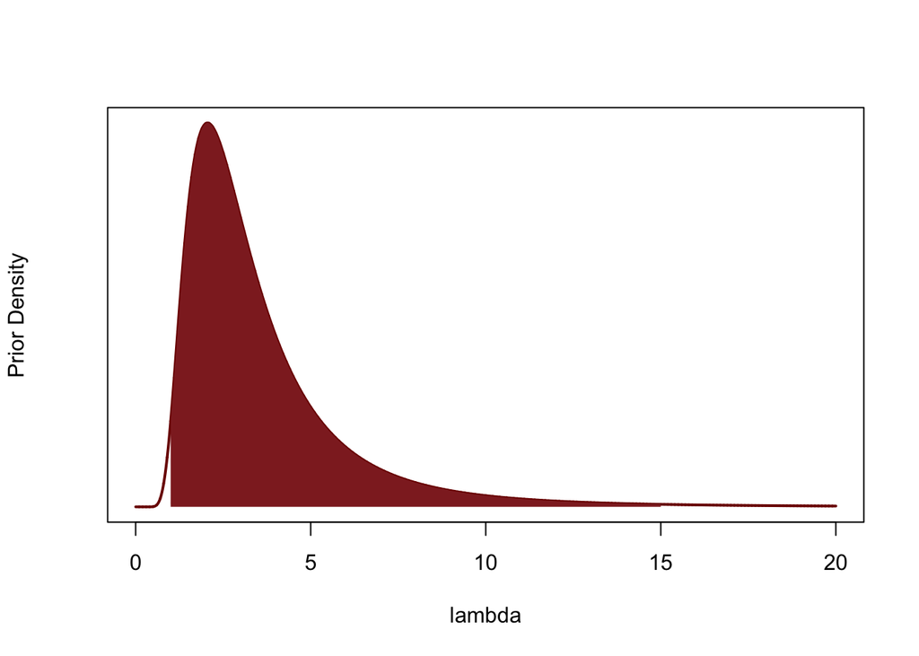

```r
lambda <- seq(0, 20, 0.001)
dens <- lapply(lambda, function(l) dgamma(1 / l, 3.48681, rate=9.21604) * (1 / l**2))
plot(lambda, dens, type="l", col=c_dark_highlight, lwd=2,
     xlab="lambda", ylab="Prior Density", yaxt='n')

lambda98 <- seq(1, 15, 0.001)
dens <- lapply(lambda98, function(l) dgamma(1 / l, 3.48681, rate=9.21604) * (1 / l**2))
lambda98 <- c(lambda98, 15, 1)
dens <- c(dens, 0, 0)

polygon(lambda98, dens, col=c_dark, border=NA)
```

Additionally, we set a prior distribution for the zero mixture probability, $\theta$ that puts only 1% probability mass below 0.1 and above 0.9 to capture our domain knowledge that some detectors are expected to fail but not all of them. Again, we want to be careful to not use the exact number of zeros in the observed data to inform this prior distribution.

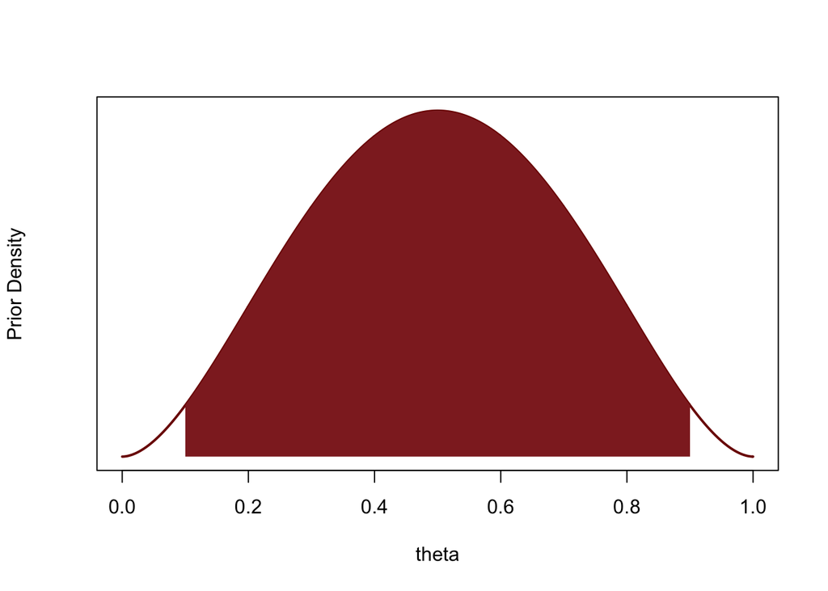

```r
theta <- seq(0, 1, 0.001)
dens <- dbeta(theta, 2.8663, 2.8663)
plot(theta, dens, type="l", col=c_dark_highlight, lwd=2,
     xlab="theta", ylab="Prior Density", yaxt='n')

theta98 <- seq(0.1, 0.9, 0.001)
dens <- dbeta(theta98, 2.8663, 2.8663)
theta98 <- c(theta98, 0.9, 0.1)
dens <- c(dens, 0, 0)

polygon(theta98, dens, col=c_dark, border=NA)
```

The new generative model is implemented in the Stan programs

```r
writeLines(readLines("generative_ensemble3.stan"))
```

```
data {
  int N;
}

generated quantities {
  real<lower=0, upper=1> theta = beta_rng(2.8663, 2.8663);
  real<lower=0> lambda = inv_gamma_rng(3.48681, 9.21604);

  int y[N] = rep_array(0, N);
  for (n in 1:N)
    if (!bernoulli_rng(theta))
      y[n] = poisson_rng(lambda);
}
```

```r
writeLines(readLines("fit_data3.stan"))
```

```
data {
  int N;
  int y[N];
}

parameters {
  real<lower=0, upper=1> theta;
  real<lower=0> lambda;
}

model {
  theta ~ beta(2.8663, 2.8663);
  lambda ~ inv_gamma(3.48681, 9.21604);

  for (n in 1:N) {
    real lpdf = poisson_lpmf(y[n] | lambda);
    if (y[n] == 0)
      target += log_mix(theta, 0, lpdf);
    else
      target += log1m(theta) + lpdf;
  }
}
```

### Step Five: Analyze the Generative Ensemble

The structure of our generative ensemble remains the same.

```r
R <- 1000
N <- 1000

simu_data <- list("N" = N)

fit <- stan(file='generative_ensemble3.stan', data=simu_data,
            iter=R, warmup=0, chains=1, refresh=R,
            seed=4838282, algorithm="Fixed_param")
```

```
Iteration:   1 / 1000 [  0%]  (Sampling)
Iteration: 1000 / 1000 [100%]  (Sampling)

 Elapsed Time: 0 seconds (Warm-up)
               0.07972 seconds (Sampling)
               0.07972 seconds (Total)
```

```r
simu_lambdas <- extract(fit)$lambda
simu_thetas <- extract(fit)$theta
simu_ys <- extract(fit)$y
```

#### Analyze the Prior Predictive Distribution

With the modified prior distributions we see a slightly different prior predictive average histogram, but one still compatible with our domain expertise.

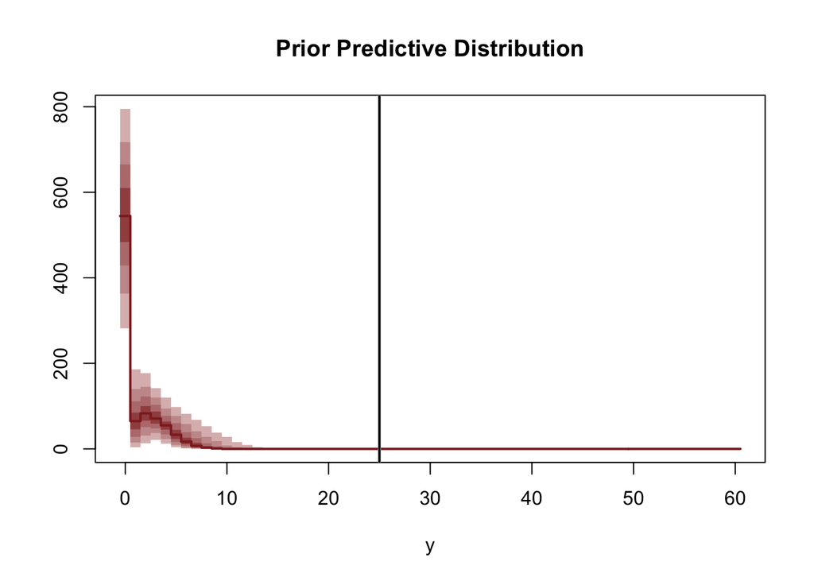

```r
B <- 60
counts <- sapply(1:R, function(r) hist(simu_ys[r,], breaks=(0:(B + 1))-0.5, plot=FALSE)$counts)
probs = c(0.1, 0.2, 0.3, 0.4, 0.5, 0.6, 0.7, 0.8, 0.9)
cred <- sapply(1:(B + 1), function(b) quantile(counts[b,], probs=probs))

idx <- rep(0:B, each=2)
x <- sapply(1:length(idx), function(b) if(b %% 2 == 0) idx[b] + 0.5 else idx[b] - 0.5)
pad_cred <- do.call(cbind, lapply(idx, function(n) cred[1:9,n + 1]))

plot(1, type="n", main="Prior Predictive Distribution",
     xlim=c(-0.5, B + 0.5), xlab="y", ylim=c(0, max(cred[9,])), ylab="")

polygon(c(x, rev(x)), c(pad_cred[1,], rev(pad_cred[9,])),
        col = c_light, border = NA)
polygon(c(x, rev(x)), c(pad_cred[2,], rev(pad_cred[8,])),
        col = c_light_highlight, border = NA)
polygon(c(x, rev(x)), c(pad_cred[3,], rev(pad_cred[7,])),
        col = c_mid, border = NA)
polygon(c(x, rev(x)), c(pad_cred[4,], rev(pad_cred[6,])),
        col = c_mid_highlight, border = NA)
lines(x, pad_cred[5,], col=c_dark, lwd=2)

abline(v=25, col="white", lty=1, lw=2.5)
abline(v=25, col="black", lty=1, lw=2)
```

Indeed we have the desired low probability for extreme observations.

```r
length(simu_ys[simu_ys > 25]) / length(simu_ys)
```

```
[1] 0.000965
```

#### Fit the Simulated Observations and Evaluate

We can now proceed to fitting each replication.

```r
tryCatch({
  registerDoParallel(makeCluster(detectCores()))

  simu_list <- t(data.matrix(data.frame(simu_lambdas, simu_thetas, simu_ys)))

  # Compile the posterior fit model
  fit_model = stan_model(file='fit_data3.stan')

  ensemble_output <- foreach(simu=simu_list,
                             .combine='cbind') %dopar% {
    simu_lambda <- simu[1]
    simu_theta <- simu[2]
    simu_y <- simu[3:(N + 2)];

    # Fit the simulated observation
    input_data <- list("N" = N, "y" = simu_y)

    capture.output(library(rstan))
    capture.output(fit <- sampling(fit_model, data=input_data, seed=4938483))

    # Compute diagnostics
    util <- new.env()
    source('stan_utility.R', local=util)

    warning_code <- util$check_all_diagnostics(fit, quiet=TRUE)

    # Compute rank of prior draw with respect to thinned posterior draws
    sbc_rank_lambda <- sum(simu_lambda < extract(fit)$lambda[seq(1, 4000 - 8, 8)])
    sbc_rank_theta <- sum(simu_theta < extract(fit)$theta[seq(1, 4000 - 8, 8)])

    # Compute posterior sensitivities
    s <- summary(fit, probs = c(), pars='lambda')$summary
    post_mean_lambda <- s[,1]
    post_sd_lambda <- s[,3]

    prior_sd_lambda <- sqrt( (9.21604)**2 / ((3.48681 - 1)**2 * (3.48681 - 1)) )

    z_score_lambda <- abs((post_mean_lambda - simu_lambda) / post_sd_lambda)
    shrinkage_lambda <- 1 - (post_sd_lambda / prior_sd_lambda)**2

    s <- summary(fit, probs = c(), pars='theta')$summary
    post_mean_theta <- s[,1]
    post_sd_theta <- s[,3]

    prior_sd_theta <- sqrt( (2.8663)**2 / (4 * (2.8663)**2 * (2 * 2.8663 + 1)) )

    z_score_theta <- abs((post_mean_theta - simu_theta) / post_sd_theta)
    shrinkage_theta <- 1 - (post_sd_theta / prior_sd_theta)**2

    c(warning_code,
      sbc_rank_lambda, z_score_lambda, shrinkage_lambda,
      sbc_rank_theta, z_score_theta, shrinkage_theta)
  }
}, finally={ stopImplicitCluster() })
```

With the non-identifiability tempered there are no diagnostic indications of fitting problems.

```r
warning_code <- ensemble_output[1,]
if (sum(warning_code) != 0) {
  print ("Some simulated posterior fits in the generative ensemble encountered problems!")
  for (r in 1:R) {
    if (warning_code[r] != 0) {
      print(sprintf('Replication %s of %s', r, R))
      util$parse_warning_code(warning_code[r])
      print(sprintf('Simulated lambda = %s', simu_lambdas[r]))
      print(sprintf('Simulated theta = %s', simu_thetas[r]))
      print(" ")
    }
  }
} else {
  print ("No posterior fits in the generative ensemble encountered problems!")
}
```

```
[1] "No posterior fits in the generative ensemble encountered problems!"
```

Similarly, the SBC histograms for both $\lambda$ and $\theta$ show no signs of errors in our fits.

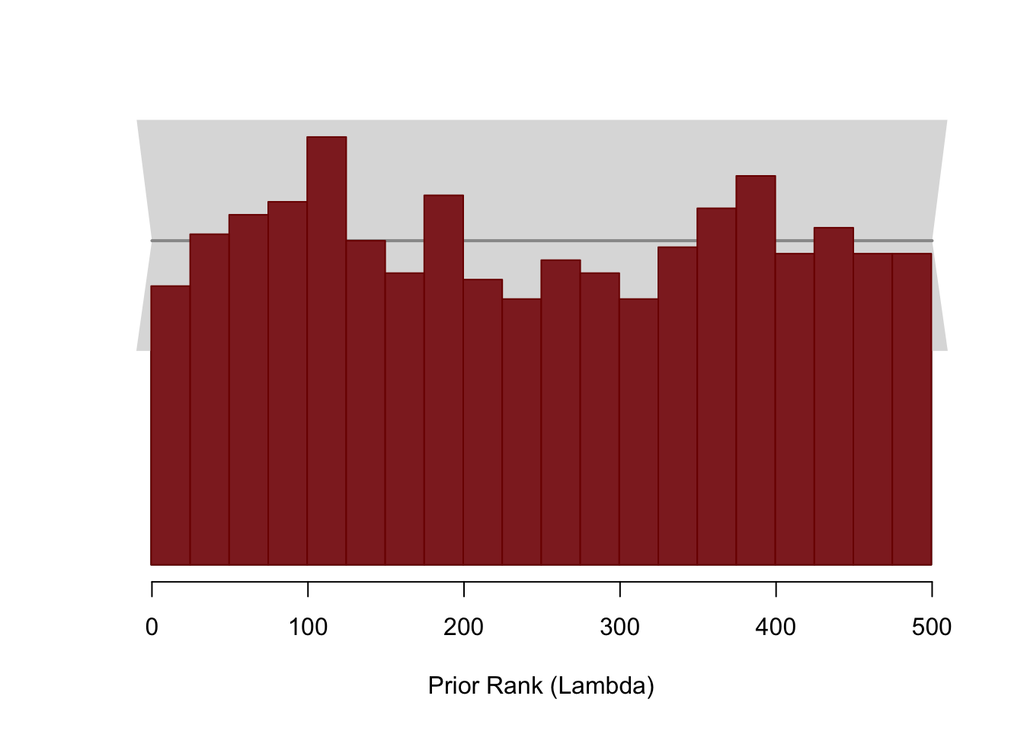

```r
sbc_rank <- ensemble_output[2,]
sbc_hist <- hist(sbc_rank, seq(0, 500, 25) - 0.5,
                 col=c_dark, border=c_dark_highlight, plot=FALSE)
plot(sbc_hist, main="", xlab="Prior Rank (Lambda)", yaxt='n', ylab="")

low <- qbinom(0.005, R, 1 / 20)
mid <- qbinom(0.5, R, 1 / 20)
high <- qbinom(0.995, R, 1 / 20)
bar_x <- c(-10, 510, 500, 510, -10, 0, -10)
bar_y <- c(high, high, mid, low, low, mid, high)

polygon(bar_x, bar_y, col=c("#DDDDDD"), border=NA)
segments(x0=0, x1=500, y0=mid, y1=mid, col=c("#999999"), lwd=2)

plot(sbc_hist, col=c_dark, border=c_dark_highlight, add=T)
```

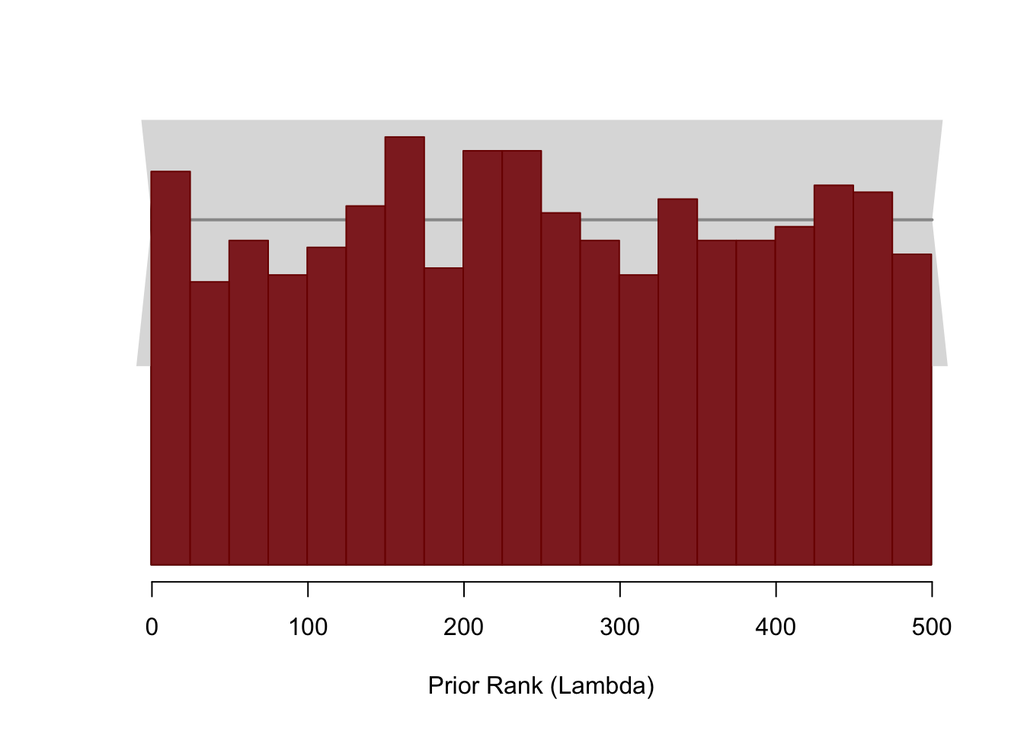

```r
sbc_rank <- ensemble_output[5,]
sbc_hist <- hist(sbc_rank, seq(0, 500, 25) - 0.5,
                 col=c_dark, border=c_dark_highlight, plot=FALSE)
plot(sbc_hist, main="", xlab="Prior Rank (Lambda)", yaxt='n', ylab="")

mean <- length(sbc_rank) / (500 / 25)
low <- mean - 3 * sqrt(mean)
high <- mean + 3 * sqrt(mean)
bar_x <- c(-10, 510, 500, 510, -10, 0, -10)
bar_y <- c(high, high, mean, low, low, mean, high)

polygon(bar_x, bar_y, col=c("#DDDDDD"), border=NA)
segments(x0=0, x1=500, y0=mean, y1=mean, col=c("#999999"), lwd=2)

plot(sbc_hist, col=c_dark, border=c_dark_highlight, add=T)
```

This leaves us to check the ensemble behavior of our recovered posterior distributions which looks reasonable for both parameters.

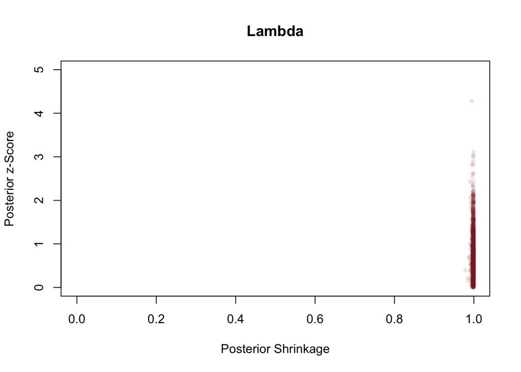

```r
z_score <- ensemble_output[3,]
shrinkage <- ensemble_output[4,]

plot(shrinkage, z_score, col=c("#8F272720"), lwd=2, pch=16, cex=0.8, main="Lambda",
     xlim=c(0, 1), xlab="Posterior Shrinkage", ylim=c(0, 5), ylab="Posterior z-Score")
```

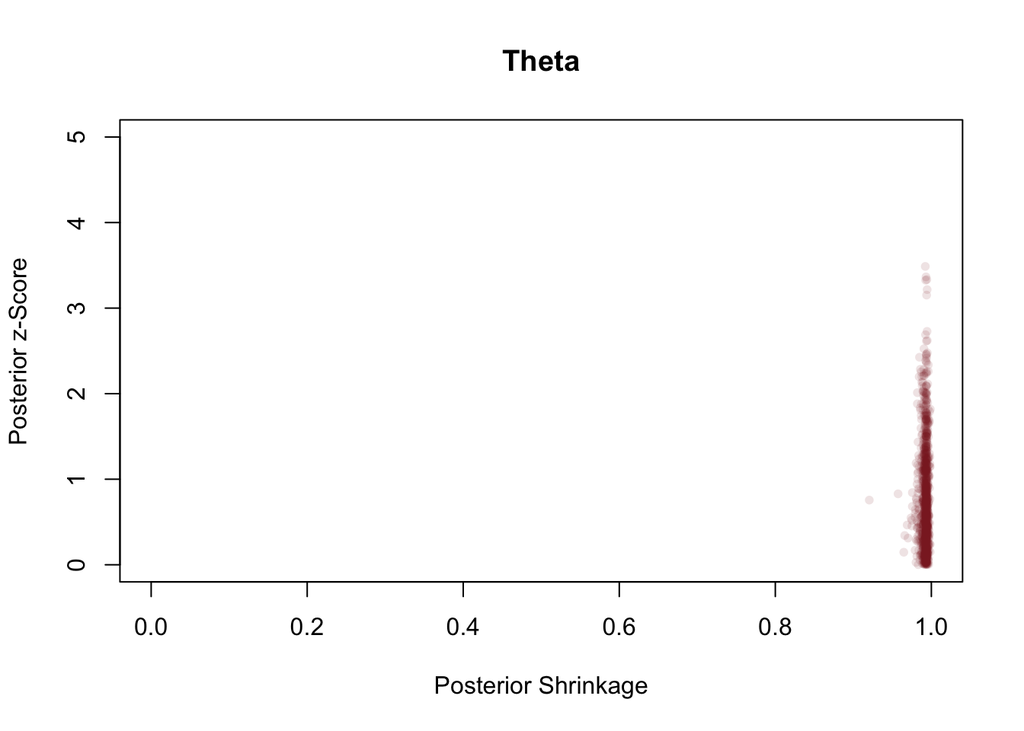

```r
z_score <- ensemble_output[6,]
shrinkage <- ensemble_output[7,]

plot(shrinkage, z_score, col=c("#8F272720"), lwd=2, pch=16, cex=0.8, main="Theta",
     xlim=c(0, 1), xlab="Posterior Shrinkage", ylim=c(0, 5), ylab="Posterior z-Score")
```

### Step Six: Fit the Observations and Evaluate

Confident in the performance of the expanded model within the scope of its own assumptions we go back to fit the observed data once again.

```r
input_data <- read_rdump('workflow.data.R')
fit <- stan(file='fit_data3_ppc.stan', data=input_data,
            seed=4938483, refresh=2000)
```

```
Gradient evaluation took 0.000305 seconds
1000 transitions using 10 leapfrog steps per transition would take 3.05 seconds.
Adjust your expectations accordingly!


Iteration:    1 / 2000 [  0%]  (Warmup)
Iteration: 1001 / 2000 [ 50%]  (Sampling)
Iteration: 2000 / 2000 [100%]  (Sampling)

 Elapsed Time: 1.81996 seconds (Warm-up)
               1.52469 seconds (Sampling)
               3.34465 seconds (Total)



Gradient evaluation took 0.000514 seconds
1000 transitions using 10 leapfrog steps per transition would take 5.14 seconds.
Adjust your expectations accordingly!


Iteration:    1 / 2000 [  0%]  (Warmup)
Iteration: 1001 / 2000 [ 50%]  (Sampling)
Iteration: 2000 / 2000 [100%]  (Sampling)

 Elapsed Time: 1.88625 seconds (Warm-up)
               1.96537 seconds (Sampling)
               3.85161 seconds (Total)



Gradient evaluation took 0.00029 seconds
1000 transitions using 10 leapfrog steps per transition would take 2.9 seconds.
Adjust your expectations accordingly!


Iteration:    1 / 2000 [  0%]  (Warmup)
Iteration: 1001 / 2000 [ 50%]  (Sampling)
Iteration: 2000 / 2000 [100%]  (Sampling)

 Elapsed Time: 1.81081 seconds (Warm-up)
               1.42826 seconds (Sampling)
               3.23906 seconds (Total)



Gradient evaluation took 0.000286 seconds
1000 transitions using 10 leapfrog steps per transition would take 2.86 seconds.
Adjust your expectations accordingly!


Iteration:    1 / 2000 [  0%]  (Warmup)
Iteration: 1001 / 2000 [ 50%]  (Sampling)
Iteration: 2000 / 2000 [100%]  (Sampling)

 Elapsed Time: 1.76549 seconds (Warm-up)
               1.75484 seconds (Sampling)
               3.52033 seconds (Total)
```

The diagnostics look good,

```r
util$check_all_diagnostics(fit)
```

```
[1] "n_eff / iter looks reasonable for all parameters"
[1] "Rhat looks reasonable for all parameters"
[1] "0 of 4000 iterations ended with a divergence (0%)"
[1] "0 of 4000 iterations saturated the maximum tree depth of 10 (0%)"
[1] "E-FMI indicated no pathological behavior"
```

and the marginal posterior distributions look reasonable.

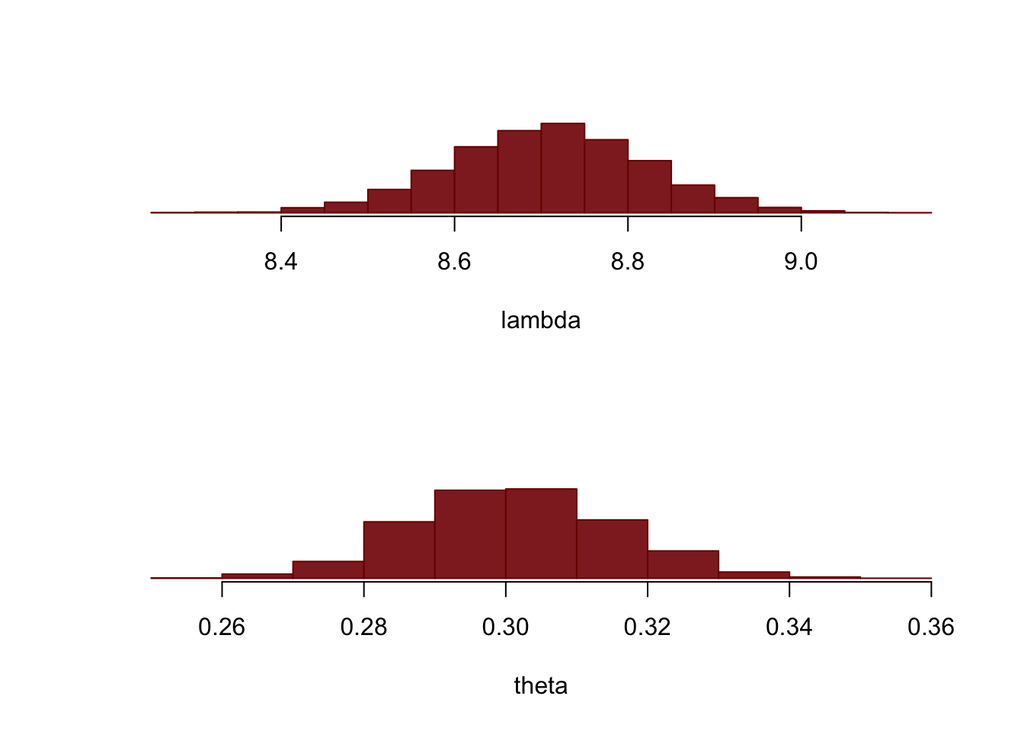

```r
params = extract(fit)

par(mfrow=c(2, 1))

hist(params$lambda, main="", xlab="lambda", yaxt='n', ylab="",
     col=c_dark, border=c_dark_highlight)

hist(params$theta, main="", xlab="theta", yaxt='n', ylab="",
     col=c_dark, border=c_dark_highlight)
```

### Step Seven: Analyze the Posterior Predictive Distribution

Excited that we might finally have a sufficient model we proceed to the posterior predictive check,

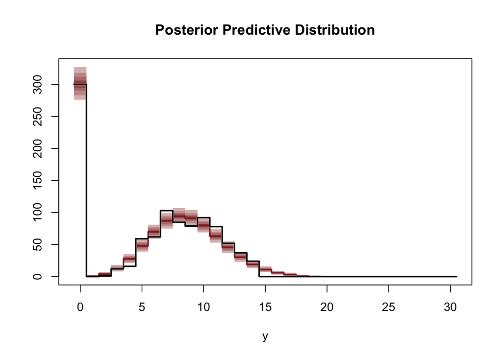

```r
B <- 30

obs_counts <- hist(input_data$y, breaks=(0:(B + 1))-0.5, plot=FALSE)$counts

idx <- rep(0:B, each=2)
x <- sapply(1:length(idx), function(b) if(b %% 2 == 0) idx[b] + 0.5 else idx[b] - 0.5)
pad_obs <- do.call(cbind, lapply(idx, function(n) obs_counts[n + 1]))

counts <- sapply(1:4000, function(n) hist(params$y_ppc[n,], breaks=(0:(B + 1))-0.5, plot=FALSE)$counts)
probs = c(0.1, 0.2, 0.3, 0.4, 0.5, 0.6, 0.7, 0.8, 0.9)
cred <- sapply(1:(B + 1), function(b) quantile(counts[b,], probs=probs))
pad_cred <- do.call(cbind, lapply(idx, function(n) cred[1:9,n + 1]))

plot(1, type="n", main="Posterior Predictive Distribution",
     xlim=c(-0.5, B + 0.5), xlab="y",
     ylim=c(0, max(c(obs_counts, cred[9,]))), ylab="")

polygon(c(x, rev(x)), c(pad_cred[1,], rev(pad_cred[9,])),
        col = c_light, border = NA)
polygon(c(x, rev(x)), c(pad_cred[2,], rev(pad_cred[8,])),
        col = c_light_highlight, border = NA)
polygon(c(x, rev(x)), c(pad_cred[3,], rev(pad_cred[7,])),
        col = c_mid, border = NA)
polygon(c(x, rev(x)), c(pad_cred[4,], rev(pad_cred[6,])),
        col = c_mid_highlight, border = NA)
lines(x, pad_cred[5,], col=c_dark, lwd=2)

lines(x, pad_obs, col="white", lty=1, lw=2.5)
lines(x, pad_obs, col="black", lty=1, lw=2)
```

only to see that the tail of the posterior predictive histogram extends pretty far beyond that in the observed data. This suggests that the detectors may be censored and unable to record values above $y = 14$. At this point we are suspicious of the exact experimental process and before considering an expanded model we need to consult with the one person who was there.

## 3.4 Fourth Iteration: Coffee Is For Closers

A principled analysis workflow is a powerful investigatory tool for identifying subtle structure in the observed data and motivating appropriate model features. There is a fine line, however, between improving the model and overfitting to the given observation. To avoid crossing this line we have to lean on our domain expertise, or the domain expertise of others.

### Step One: Conceptual Analysis

Suspicious of the experimental setup under which the data were collected we ask to meet with the student who ran the experiment. When we bring up the odd behavior we saw the student seems nonchalant. “Oh, you mean like when the detectors didn’t read out anything at all?” they say. “I just repeated the measurement for each detector until they reported an actual value.” they say.

And there it is. The readout system for detectors seems to be vulnerable to overloading when the counts surpass a given value, returning no value at all. When the student repeated the measurement for detectors in this state they unintentionally induced a *censored obsevation* where the Poisson distribution for the observations is cutoff at a certain value.

### Step Two: Define Observations

The observation space does not change.

```r
writeLines(readLines("fit_data4.stan", n=4))
```

```
data {
  int N;
  int y[N];
}
```

### Step Three: Identify Relevant Summary Statistics

The same histogram summary remains appropriate.

### Step Four: Build a Generative Model

We now have to augment out generative model to account for the censoring of the counts. Ideally we would treat the censoring threshold as a systematic parameter here and infer it with uncertainties to avoid overfitting to our one observation. Unfortunately that model is a bit ungainly, so for pedagogical simplification we will take the fixed threshold of $y = 14$ implied by the observed data assuming that it too is consistent with our hypothetical domain expertise.

```r
writeLines(readLines("generative_ensemble4.stan"))
```

```
data {
  int N;
}

transformed data {
  int U = 14;
}

generated quantities {
  real<lower=0, upper=1> theta = beta_rng(2.8663, 2.8663);
  real<lower=0> lambda = inv_gamma_rng(3.48681, 9.21604);

  int y[N] = rep_array(0, N);
  for (n in 1:N) {
    if (!bernoulli_rng(theta)) {
      y[n] = U + 1;
      while (y[n] > U)
        y[n] = poisson_rng(lambda);
    }
  }
}
```

```r
writeLines(readLines("fit_data4.stan"))
```

```
data {
  int N;
  int y[N];
}

transformed data {
  int U = 14;
}

parameters {
  real<lower=0, upper=1> theta;
  real<lower=0> lambda;
}

model {
  theta ~ beta(2.8663, 2.8663);
  lambda ~ inv_gamma(3.48681, 9.21604);

  for (n in 1:N) {
    real lpdf = poisson_lpmf(y[n] | lambda) - poisson_lcdf(U | lambda);
    if (y[n] == 0)
      target += log_mix(theta, 0, lpdf);
    else
      target += log1m(theta) + lpdf;
  }
}
```

### Step Five: Analyze the Generative Ensemble

We dutifully generate our ensemble.

```r
R <- 1000
N <- 1000

simu_data <- list("N" = N)

fit <- stan(file='generative_ensemble4.stan', data=simu_data,
            iter=R, warmup=0, chains=1, refresh=R,
            seed=4838282, algorithm="Fixed_param")
```

```
Iteration:   1 / 1000 [  0%]  (Sampling)
Iteration: 1000 / 1000 [100%]  (Sampling)

 Elapsed Time: 0 seconds (Warm-up)
               2.62848 seconds (Sampling)
               2.62848 seconds (Total)
```

```r
simu_lambdas <- extract(fit)$lambda
simu_thetas <- extract(fit)$theta
simu_ys <- extract(fit)$y
```

#### Analyze the Prior Predictive Distribution

The prior predictive average histogram now exhibits features of the zero-inflation and the censoring.

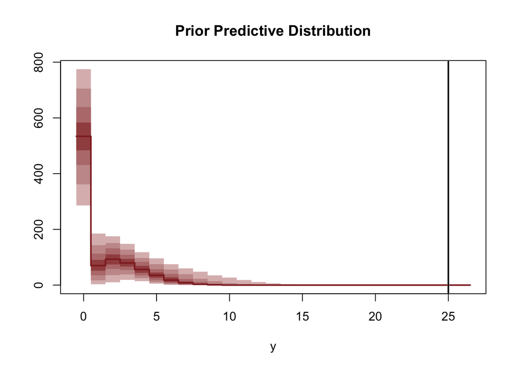

```r
B <- 26
counts <- sapply(1:R, function(r) hist(simu_ys[r,], breaks=(0:(B + 1))-0.5, plot=FALSE)$counts)
probs = c(0.1, 0.2, 0.3, 0.4, 0.5, 0.6, 0.7, 0.8, 0.9)
cred <- sapply(1:(B + 1), function(b) quantile(counts[b,], probs=probs))

idx <- rep(0:B, each=2)
x <- sapply(1:length(idx), function(b) if(b %% 2 == 0) idx[b] + 0.5 else idx[b] - 0.5)
pad_cred <- do.call(cbind, lapply(idx, function(n) cred[1:9,n + 1]))

plot(1, type="n", main="Prior Predictive Distribution",
     xlim=c(-0.5, B + 0.5), xlab="y", ylim=c(0, max(cred[9,])), ylab="")

polygon(c(x, rev(x)), c(pad_cred[1,], rev(pad_cred[9,])),
        col = c_light, border = NA)
polygon(c(x, rev(x)), c(pad_cred[2,], rev(pad_cred[8,])),
        col = c_light_highlight, border = NA)
polygon(c(x, rev(x)), c(pad_cred[3,], rev(pad_cred[7,])),
        col = c_mid, border = NA)
polygon(c(x, rev(x)), c(pad_cred[4,], rev(pad_cred[6,])),
        col = c_mid_highlight, border = NA)
lines(x, pad_cred[5,], col=c_dark, lwd=2)

abline(v=25, col="white", lty=1, lw=2.5)
abline(v=25, col="black", lty=1, lw=2)
```

With the censoring we now have exactly zero prior predictive probability above the extreme observation scale derived from our domain expertise.

```r
length(simu_ys[simu_ys > 25]) / length(simu_ys)
```

```
[1] 0
```

#### Fit the Simulated Observations and Evaluate

We contine to fitting each replication in our generative ensemble.

```r
tryCatch({
  registerDoParallel(makeCluster(detectCores()))

  simu_list <- t(data.matrix(data.frame(simu_lambdas, simu_thetas, simu_ys)))

  # Compile the posterior fit model
  fit_model = stan_model(file='fit_data4.stan')

  ensemble_output <- foreach(simu=simu_list,
                             .combine='cbind') %dopar% {
    simu_lambda <- simu[1]
    simu_theta <- simu[2]
    simu_y <- simu[3:(N + 2)];

    # Fit the simulated observation
    input_data <- list("N" = N, "y" = simu_y)

    capture.output(library(rstan))
    capture.output(fit <- sampling(fit_model, data=input_data, seed=4938483))

    # Compute diagnostics
    util <- new.env()
    source('stan_utility.R', local=util)

    warning_code <- util$check_all_diagnostics(fit, quiet=TRUE)

    # Compute rank of prior draw with respect to thinned posterior draws
    sbc_rank_lambda <- sum(simu_lambda < extract(fit)$lambda[seq(1, 4000 - 8, 8)])
    sbc_rank_theta <- sum(simu_theta < extract(fit)$theta[seq(1, 4000 - 8, 8)])

    # Compute posterior sensitivities
    s <- summary(fit, probs = c(), pars='lambda')$summary
    post_mean_lambda <- s[,1]
    post_sd_lambda <- s[,3]

    prior_sd_lambda <- sqrt( (9.21604)**2 / ((3.48681 - 1)**2 * (3.48681 - 1)) )

    z_score_lambda <- abs((post_mean_lambda - simu_lambda) / post_sd_lambda)
    shrinkage_lambda <- 1 - (post_sd_lambda / prior_sd_lambda)**2

    s <- summary(fit, probs = c(), pars='theta')$summary
    post_mean_theta <- s[,1]
    post_sd_theta <- s[,3]

    prior_sd_theta <- sqrt( (2.8663)**2 / (4 * (2.8663)**2 * (2 * 2.8663 + 1)) )

    z_score_theta <- abs((post_mean_theta - simu_theta) / post_sd_theta)
    shrinkage_theta <- 1 - (post_sd_theta / prior_sd_theta)**2

    c(warning_code,
      sbc_rank_lambda, z_score_lambda, shrinkage_lambda,
      sbc_rank_theta, z_score_theta, shrinkage_theta)
  }
}, finally={ stopImplicitCluster() })
```

The diagnostics all look clean.

```r
warning_code <- ensemble_output[1,]
if (sum(warning_code) != 0) {
  print ("Some simulated posterior fits in the generative ensemble encountered problems!")
  for (r in 1:R) {
    if (warning_code[r] != 0) {
      print(sprintf('Replication %s of %s', r, R))
      util$parse_warning_code(warning_code[r])
      print(sprintf('Simulated lambda = %s', simu_lambdas[r]))
      print(sprintf('Simulated theta = %s', simu_thetas[r]))
      print(" ")
    }
  }
} else {
  print ("No posterior fits in the generative ensemble encountered problems!")
}
```

```
[1] "No posterior fits in the generative ensemble encountered problems!"
```

Similarly the SBC histograms exhibit no problems.

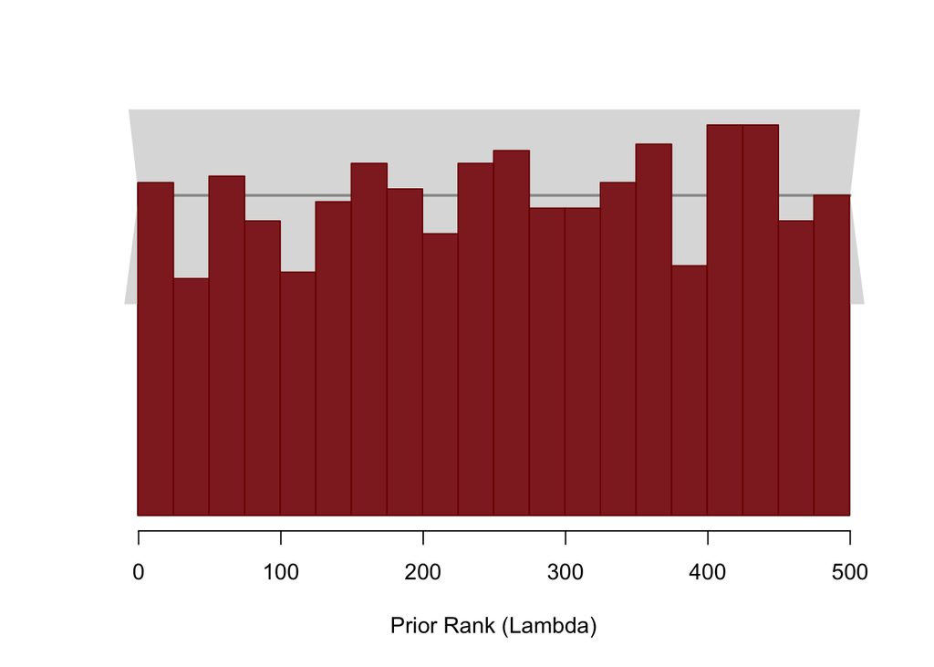

```r
sbc_rank <- ensemble_output[2,]
sbc_hist <- hist(sbc_rank, seq(0, 500, 25) - 0.5,
                 col=c_dark, border=c_dark_highlight, plot=FALSE)
plot(sbc_hist, main="", xlab="Prior Rank (Lambda)", yaxt='n', ylab="")

low <- qbinom(0.005, R, 1 / 20)
mid <- qbinom(0.5, R, 1 / 20)
high <- qbinom(0.995, R, 1 / 20)
bar_x <- c(-10, 510, 500, 510, -10, 0, -10)
bar_y <- c(high, high, mid, low, low, mid, high)

polygon(bar_x, bar_y, col=c("#DDDDDD"), border=NA)
segments(x0=0, x1=500, y0=mid, y1=mid, col=c("#999999"), lwd=2)

plot(sbc_hist, col=c_dark, border=c_dark_highlight, add=T)
```

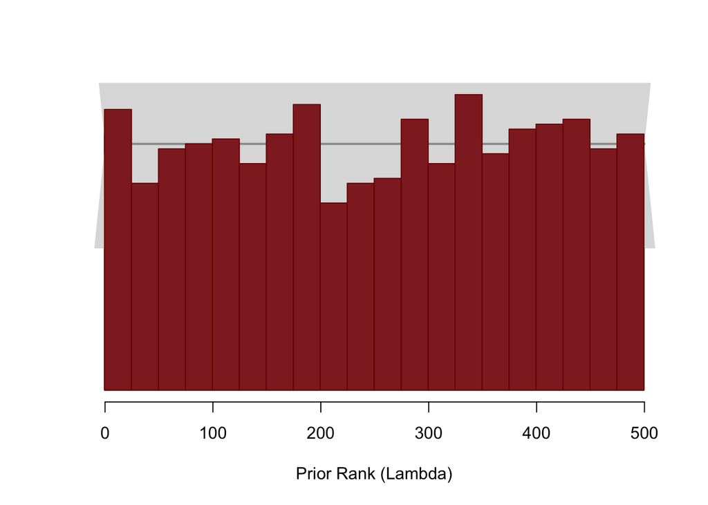

```r
sbc_rank <- ensemble_output[5,]
sbc_hist <- hist(sbc_rank, seq(0, 500, 25) - 0.5,
                 col=c_dark, border=c_dark_highlight, plot=FALSE)
plot(sbc_hist, main="", xlab="Prior Rank (Lambda)", yaxt='n', ylab="")

mean <- length(sbc_rank) / (500 / 25)
low <- mean - 3 * sqrt(mean)
high <- mean + 3 * sqrt(mean)
bar_x <- c(-10, 510, 500, 510, -10, 0, -10)
bar_y <- c(high, high, mean, low, low, mean, high)

polygon(bar_x, bar_y, col=c("#DDDDDD"), border=NA)
segments(x0=0, x1=500, y0=mean, y1=mean, col=c("#999999"), lwd=2)

plot(sbc_hist, col=c_dark, border=c_dark_highlight, add=T)
```

Moreover, the recovered posteriors for each fit perform reasonable well.

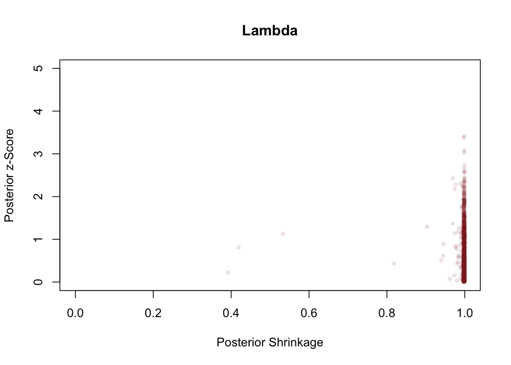

```r
z_score <- ensemble_output[3,]
shrinkage <- ensemble_output[4,]

plot(shrinkage, z_score, col=c("#8F272720"), lwd=2, pch=16, cex=0.8, main="Lambda",
     xlim=c(0, 1), xlab="Posterior Shrinkage", ylim=c(0, 5), ylab="Posterior z-Score")
```

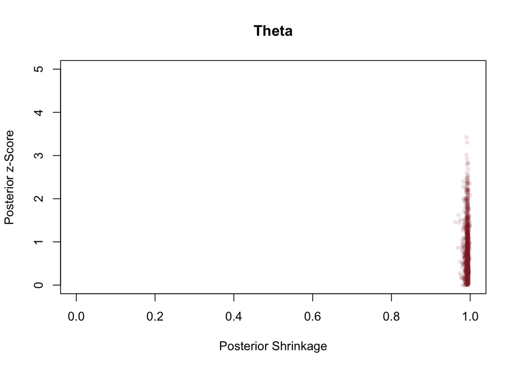

```r
z_score <- ensemble_output[6,]
shrinkage <- ensemble_output[7,]

plot(shrinkage, z_score, col=c("#8F272720"), lwd=2, pch=16, cex=0.8, main="Theta",
    xlim=c(0, 1), xlab="Posterior Shrinkage", ylim=c(0, 5), ylab="Posterior z-Score")
```

### Step Six: Fit the Observations and Evaluate

Exhausted, we march on to fitting the observed data.

```r
input_data <- read_rdump('workflow.data.R')
fit <- stan(file='fit_data4_ppc.stan', data=input_data,
            seed=4938483, refresh=2000)
```

```
Gradient evaluation took 0.001591 seconds
1000 transitions using 10 leapfrog steps per transition would take 15.91 seconds.
Adjust your expectations accordingly!


Iteration:    1 / 2000 [  0%]  (Warmup)
Iteration: 1001 / 2000 [ 50%]  (Sampling)
Iteration: 2000 / 2000 [100%]  (Sampling)

 Elapsed Time: 5.55821 seconds (Warm-up)
               6.42832 seconds (Sampling)
               11.9865 seconds (Total)



Gradient evaluation took 0.000755 seconds
1000 transitions using 10 leapfrog steps per transition would take 7.55 seconds.
Adjust your expectations accordingly!


Iteration:    1 / 2000 [  0%]  (Warmup)
Iteration: 1001 / 2000 [ 50%]  (Sampling)
Iteration: 2000 / 2000 [100%]  (Sampling)

 Elapsed Time: 5.32985 seconds (Warm-up)
               5.11584 seconds (Sampling)
               10.4457 seconds (Total)



Gradient evaluation took 0.000741 seconds
1000 transitions using 10 leapfrog steps per transition would take 7.41 seconds.
Adjust your expectations accordingly!


Iteration:    1 / 2000 [  0%]  (Warmup)
Iteration: 1001 / 2000 [ 50%]  (Sampling)
Iteration: 2000 / 2000 [100%]  (Sampling)

 Elapsed Time: 6.00023 seconds (Warm-up)
               6.14659 seconds (Sampling)
               12.1468 seconds (Total)



Gradient evaluation took 0.000765 seconds
1000 transitions using 10 leapfrog steps per transition would take 7.65 seconds.
Adjust your expectations accordingly!


Iteration:    1 / 2000 [  0%]  (Warmup)
Iteration: 1001 / 2000 [ 50%]  (Sampling)
Iteration: 2000 / 2000 [100%]  (Sampling)

 Elapsed Time: 5.37169 seconds (Warm-up)
               3.71894 seconds (Sampling)
               9.09064 seconds (Total)
```

The diagnostics are clean,

```r
util$check_all_diagnostics(fit)
```

```
[1] "n_eff / iter looks reasonable for all parameters"
[1] "Rhat looks reasonable for all parameters"
[1] "0 of 4000 iterations ended with a divergence (0%)"
[1] "0 of 4000 iterations saturated the maximum tree depth of 10 (0%)"
[1] "E-FMI indicated no pathological behavior"
```

and the marginal posteriors are reasonable.

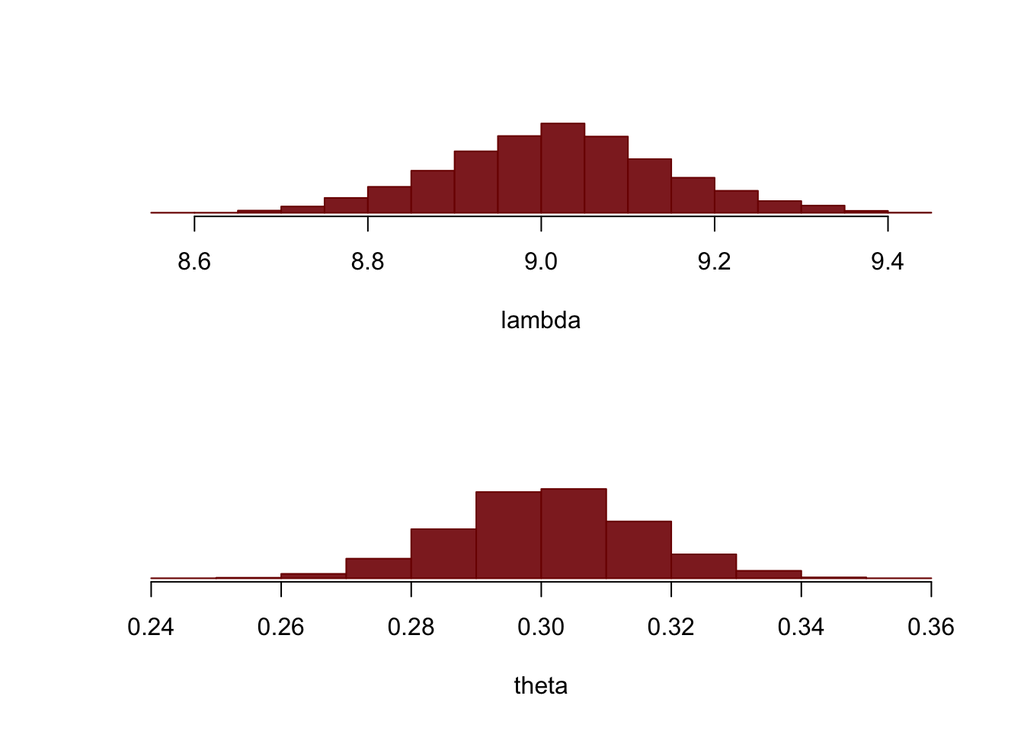

```r
params = extract(fit)

par(mfrow=c(2, 1))

hist(params$lambda, main="", xlab="lambda", yaxt='n', ylab="",
col=c_dark, border=c_dark_highlight)

hist(params$theta, main="", xlab="theta", yaxt='n', ylab="",
col=c_dark, border=c_dark_highlight)
```

### Step Seven: Analyze the Posterior Predictive Distribution

Anxiously we move onto the posterior predictive check,

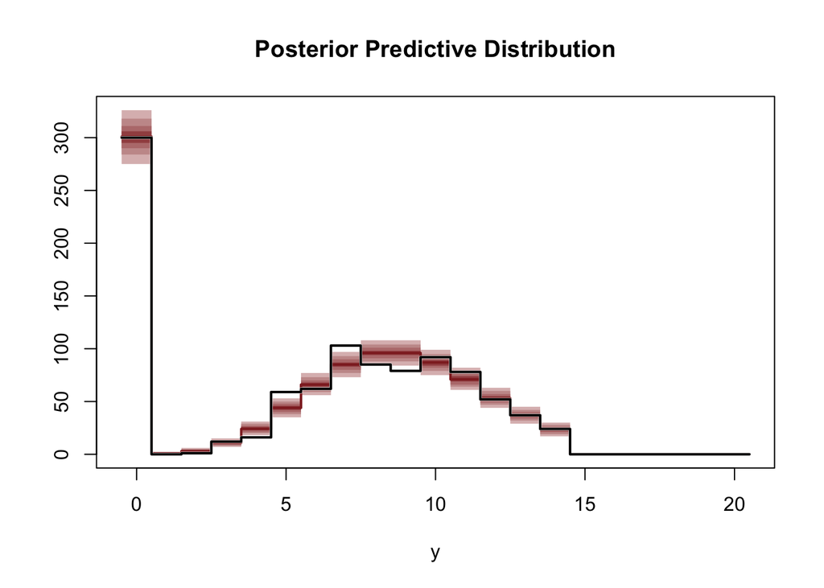

```r
B <- 20

obs_counts <- hist(input_data$y, breaks=(0:(B + 1))-0.5, plot=FALSE)$counts

idx <- rep(0:B, each=2)
x <- sapply(1:length(idx), function(b) if(b %% 2 == 0) idx[b] + 0.5 else idx[b] - 0.5)
pad_obs <- do.call(cbind, lapply(idx, function(n) obs_counts[n + 1]))

counts <- sapply(1:4000, function(n) hist(params$y_ppc[n,], breaks=(0:(B + 1))-0.5, plot=FALSE)$counts)
probs = c(0.1, 0.2, 0.3, 0.4, 0.5, 0.6, 0.7, 0.8, 0.9)
cred <- sapply(1:(B + 1), function(b) quantile(counts[b,], probs=probs))
pad_cred <- do.call(cbind, lapply(idx, function(n) cred[1:9,n + 1]))

plot(1, type="n", main="Posterior Predictive Distribution",
     xlim=c(-0.5, B + 0.5), xlab="y",
     ylim=c(0, max(c(obs_counts, cred[9,]))), ylab="")

polygon(c(x, rev(x)), c(pad_cred[1,], rev(pad_cred[9,])),
        col = c_light, border = NA)
polygon(c(x, rev(x)), c(pad_cred[2,], rev(pad_cred[8,])),
        col = c_light_highlight, border = NA)
polygon(c(x, rev(x)), c(pad_cred[3,], rev(pad_cred[7,])),
        col = c_mid, border = NA)
polygon(c(x, rev(x)), c(pad_cred[4,], rev(pad_cred[6,])),
        col = c_mid_highlight, border = NA)
lines(x, pad_cred[5,], col=c_dark, lwd=2)

lines(x, pad_obs, col="white", lty=1, lw=2.5)
lines(x, pad_obs, col="black", lty=1, lw=2)
```

only to see no tension between the observed data and the posterior prediction. We finally have a model that captures the intricacies of our observed data!

Satisfied in our detector detective work we send out the results to our colleagues and start drafting a note instructing students what to do when the detectors do not report any counts at all.

# 4 Discussion

By very carefully following a principled Bayesian workflow we were able to answer the questions proposed in Section One and develop a model that incorporated enough domain expertise to achieve a reasonable fit to our observed data. Indeed the progression of the workflow itself helped to inform which domain expertise we need to incorporate, and in particular when we needed to follow up with colleagues to better understand the circumstances of the experiment. By minding this domain expertise, and not simply fitting to the potentially irrelevant details of the observed data, we ensured a final model that is robust to overfitting and should generalize well to application on new observations.

That said, this workflow makes no claim that the final model is correct in any absolute sense. Our ability to critique the model is limited by the specific questions we ask and the information encoded in the observed data. Indeed more thorough questions or additional data might demonstrate limitations of our concluding model and the need for further iterations. Our detectors, for example, may not have identical responses, and that may response may not be so static in time. Similarly the source being measured may not emit particles uniformly in time or space. A principled workflow doesn’t yield the correct model but rather a model that has been iteratively improved to meet the needs of a given inferential task.

While the workflow is structured, it is not automatic and requires careful and customized consideration of our domain expertise in the scope of our modeling assumptions at each step. Moreover the workflow isn’t cheap, requiring significant computational resources to fully exploit it even on this relatively simple example. That investment of time and resources, however, provides a powerful model robust to many of the pathologies that can lead to biased inferences and faulty scientific insights.

# 5 Acknowledgements

I thank Sean Talts for helpful comments.

# 6 Original Computing Environment

```r
writeLines(readLines(file.path(Sys.getenv("HOME"), ".R/Makevars")))
```

```
CXXFLAGS=-O3 -mtune=native -march=native -Wno-unused-variable -Wno-unused-function -Wno-macro-redefined

CC=clang
CXX=clang++ -arch x86_64 -ftemplate-depth-256
```

```
 setting  value
 version  R version 3.4.2 (2017-09-28)
 system   x86_64, darwin15.6.0
 ui       X11
 language (EN)
 collate  en_US.UTF-8
 tz       Africa/Nairobi
 date     2018-06-11
```

```
Packages -----------------------------------------------------------------
```

```
 package      * version   date       source
 BH             1.65.0-1  2017-08-24 CRAN (R 3.4.1)
 colorspace     1.3-2     2016-12-14 CRAN (R 3.4.0)
 dichromat      2.0-0     2013-01-24 CRAN (R 3.4.0)
 digest         0.6.12    2017-01-27 CRAN (R 3.4.0)
 ggplot2      * 2.2.1     2016-12-30 CRAN (R 3.4.0)
 graphics     * 3.4.2     2017-10-04 local
 grDevices    * 3.4.2     2017-10-04 local
 grid           3.4.2     2017-10-04 local
 gridExtra      2.3       2017-09-09 CRAN (R 3.4.1)
 gtable         0.2.0     2016-02-26 CRAN (R 3.4.0)
 inline         0.3.14    2015-04-13 CRAN (R 3.4.0)
 labeling       0.3       2014-08-23 CRAN (R 3.4.0)
 lattice        0.20-35   2017-03-25 CRAN (R 3.4.2)
 lazyeval       0.2.1     2017-10-29 CRAN (R 3.4.2)
 magrittr       1.5       2014-11-22 CRAN (R 3.4.0)
 MASS           7.3-47    2017-02-26 CRAN (R 3.4.2)
 Matrix         1.2-11    2017-08-21 CRAN (R 3.4.2)
 methods      * 3.4.2     2017-10-04 local
 munsell        0.4.3     2016-02-13 CRAN (R 3.4.0)
 plyr           1.8.4     2016-06-08 CRAN (R 3.4.0)
 R6             2.2.2     2017-06-17 CRAN (R 3.4.0)
 RColorBrewer   1.1-2     2014-12-07 CRAN (R 3.4.0)
 Rcpp           0.12.13   2017-09-28 CRAN (R 3.4.2)
 RcppEigen      0.3.3.3.0 2017-05-01 CRAN (R 3.4.0)
 reshape2       1.4.2     2016-10-22 CRAN (R 3.4.0)
 rlang          0.1.4     2017-11-05 CRAN (R 3.4.2)
 rstan        * 2.17.3    2018-01-20 CRAN (R 3.4.2)
 scales         0.5.0     2017-08-24 CRAN (R 3.4.1)
 StanHeaders  * 2.17.2    2018-01-20 CRAN (R 3.4.2)
 stats        * 3.4.2     2017-10-04 local
 stats4         3.4.2     2017-10-04 local
 stringi        1.1.5     2017-04-07 CRAN (R 3.4.0)
 stringr        1.2.0     2017-02-18 CRAN (R 3.4.0)
 tibble         1.3.4     2017-08-22 CRAN (R 3.4.1)
 tools          3.4.2     2017-10-04 local
 utils        * 3.4.2     2017-10-04 local
 viridisLite    0.2.0     2017-03-24 CRAN (R 3.4.0)
```

# References

Betancourt, Michael. 2015. “A Unified Treatment of Predictive Model Comparison,” June.

———. 2018. “Calibrating Model-Based Inferences and Decisions,” March.

Gabry, Jonah, Daniel Simpson, Aki Vehtari, Michael Betancourt, and Andrew Gelman. 2017. “Visualization in Bayesian Workflow,” September.

Gelman, Andrew, Daniel Simpson, and Michael Betancourt. 2017. “The Prior Can Generally Only Be Understood in the Context of the Likelihood,” August.

Good, I.J. 1950. *Probability and the Weighing of Evidence*. New York: Hafners.

Rubin, Donald B. 1984. “Bayesianly Justifiable and Relevant Frequency Calculations for the Applied Statistician.” *Ann. Statist.* 12 (4): 1151–72.

Talts, Sean, Michael Betancourt, Daniel Simpson, Aki Vehtari, and Andrew Gelman. 2018. “Validating Bayesian Inference Algorithms with Simulation-Based Calibration,” April.